# Código_TFM

[figure not shown]

Montserrat Rodriguez Capece

Máster universitario en Ciencia de Datos

Junio de 2021

# Trabajo Final de Master

**Contenido**  
3.1. Lectura de datos  
3.2. Preproceso y Exploración de datos  
3.2.1. Preproceso  
3.2.1.1. Variables cualitativas  
3.2.1.2. Variables cuantitativas  
3.2.2. Análisis Exploratorio de Datos  
3.2.2.1. Análisis Univariante  
3.2.2.2. Análisis Bivariante  
3.3. Análisis de Datos  
3.3.1. Agrupamiento Jerárquico  
3.3.2. Árboles de Decisión

## 3.1. LECTURA DE LOS DATOS

```python
## Cargamos paquete necesarios

import pandas as pd
import numpy as np
import seaborn as sns
from datetime import datetime, date, time, timedelta
import matplotlib.pyplot as plt
%matplotlib inline

from scipy.cluster.hierarchy import dendrogram, linkage, fcluster
from sklearn.cluster import AgglomerativeClustering
from sklearn import linear_model
from sklearn.metrics import mean_squared_error, r2_score, accuracy_score, confusion_matrix
from sklearn.model_selection import train_test_split
from sklearn.tree import DecisionTreeClassifier
```

```python
data = pd.read_csv("SearchResults.csv", sep=',')
data.shape
```

```
(10000, 27)
```

```python
# Validamos lectura
print("El total de número de filas de los datos es:", len(data))
print("Los elementos en el diccionario de datos son:", data.keys())
```

```
El total de número de filas de los datos es: 10000
Los elementos en el diccionario de datos son: Index(['Rank', 'NCT Number', 'Title', 'Acronym', 'Status', 'Study Results',
       'Conditions', 'Interventions', 'Outcome Measures',
       'Sponsor/Collaborators', 'Gender', 'Age', 'Phases', 'Enrollment',
       'Funded Bys', 'Study Type', 'Study Designs', 'Other IDs', 'Start Date',
       'Primary Completion Date', 'Completion Date', 'First Posted',
       'Results First Posted', 'Last Update Posted', 'Locations',
       'Study Documents', 'URL'],
      dtype='object')
```

```python
# Visualizamos los datos cargados
data.head(5)
```

|  | Rank | NCT Number | Title | Acronym | Status | Study Results | Conditions | Interventions | Outcome Measures | Sponsor/Collaborators | ... | Other IDs | Start Date | Primary Completion Date | Completion Date | First Posted | Results First Posted | Last Update Posted | Locations | Study Documents | URL |
| --- | --- | --- | --- | --- | --- | --- | --- | --- | --- | --- | --- | --- | --- | --- | --- | --- | --- | --- | --- | --- | --- |
| 0 | 1 | NCT01464957 | Skin Cancer Prevention in a Pediatric Population | NaN | Completed | No Results Available | Skin Cancer | Behavioral: Semi-tailored newsletter | sun protection behavior scale\|Nevus counts | University of Colorado, Denver\|Kaiser Permanen... | ... | 96-0014\|R01CA074592 | November 2003 | September 2007 | September 2008 | November 4, 2011 | NaN | January 25, 2013 | University of Colorado Denver, Aurora, Colorad... | NaN | https://ClinicalTrials.gov/show/NCT01464957 |
| 1 | 2 | NCT01544569 | Studying Biomarkers in Samples From Young Pati... | NaN | Completed | No Results Available | Kidney Cancer | Genetic: DNA analysis\|Genetic: fluorescence in... | Expression and function of transposons in rhab... | Children's Oncology Group\|National Cancer Inst... | ... | AREN12B3\|COG-AREN12B3\|CDR0000727229\|NCI-2012-0... | March 2012 | May 2016 | NaN | March 6, 2012 | NaN | May 18, 2016 | NaN | NaN | https://ClinicalTrials.gov/show/NCT01544569 |
| 2 | 3 | NCT04789720 | Using Information Technology to Improve Outcom... | SyMon-SAYS | Not yet recruiting | No Results Available | Cancer | Behavioral: Symptom Monitoring & Systematic As... | Adherence to intervention\|Overall symptom burd... | Northwestern University\|Ann & Robert H Lurie C... | ... | 1U01CA246612-01 | April 2021 | June 2024 | June 2024 | March 10, 2021 | NaN | March 19, 2021 | NaN | NaN | https://ClinicalTrials.gov/show/NCT04789720 |
| 3 | 4 | NCT01096134 | Mother - Daughter Initiative (MDI) in Cervical... | MDI | Completed | No Results Available | Cervical Cancer | Biological: HPV Vaccine (Gardasil) | Determine the population coverage of HPV vacci... | Jhpiego\|Merck Sharp & Dohme Corp. | ... | 36448 | January 2011 | November 2012 | November 2012 | March 30, 2010 | NaN | October 12, 2015 | Minglanilla, Cebu, Philippines\|Los Banos, Quez... | NaN | https://ClinicalTrials.gov/show/NCT01096134 |
| 4 | 5 | NCT01835509 | Group Intervention to Increase Physical Activi... | NaN | Completed | No Results Available | Pediatric Cancer | Behavioral: Intervention, Camp plus reunions | Change in level of physical activity\|Change in... | Sidney Kimmel Comprehensive Cancer Center at J... | ... | J12136 | February 2013 | February 2014 | February 2014 | April 19, 2013 | NaN | February 25, 2014 | Sidney Kimmel Comprehensive Cancer Center, Bal... | NaN | https://ClinicalTrials.gov/show/NCT01835509 |

5 rows × 27 columns

```python
# Visualizamos los datos cargados
data.iloc[0:5,9:18]
```

|  | Sponsor/Collaborators | Gender | Age | Phases | Enrollment | Funded Bys | Study Type | Study Designs | Other IDs |
| --- | --- | --- | --- | --- | --- | --- | --- | --- | --- |
| 0 | University of Colorado, Denver\|Kaiser Permanen... | All | 5 Years to 6 Years (Child) | Phase 2 | 867.0 | Other\|NIH | Interventional | Allocation: Randomized\|Intervention Model: Par... | 96-0014\|R01CA074592 |
| 1 | Children's Oncology Group\|National Cancer Inst... | All | up to 1 Year (Child) | NaN | 50.0 | Other\|NIH | Observational | Observational Model: Case-Only\|Time Perspectiv... | AREN12B3\|COG-AREN12B3\|CDR0000727229\|NCI-2012-0... |
| 2 | Northwestern University\|Ann & Robert H Lurie C... | All | 8 Years to 17 Years (Child) | Not Applicable | 200.0 | Other\|NIH | Interventional | Allocation: Randomized\|Intervention Model: Par... | 1U01CA246612-01 |
| 3 | Jhpiego\|Merck Sharp & Dohme Corp. | Female | 9 Years to 13 Years (Child) | Not Applicable | 8000.0 | Other\|Industry | Interventional | Allocation: N/A\|Intervention Model: Single Gro... | 36448 |
| 4 | Sidney Kimmel Comprehensive Cancer Center at J... | All | 8 Years to 12 Years (Child) | Early Phase 1 | 20.0 | Other | Interventional | Allocation: Randomized\|Intervention Model: Par... | J12136 |

## 3.2. PREPROCESO Y EXPLORACIÓN DE DATOS

### 3.2.1. Preproceso

#### 3.2.1.1. Variables cualitativas

```python
# Vemos cuántos variables contienen missings
data.isnull().sum()
# Columns_with_na_dropped = data.dropna(axis=1)
```

```
Rank                          0
NCT Number                    0
Title                         0
Acronym                    8212
Status                        0
Study Results                 0
Conditions                    4
Interventions              1386
Outcome Measures           1179
Sponsor/Collaborators         0
Gender                       56
Age                           0
Phases                     3063
Enrollment                  462
Funded Bys                    0
Study Type                    0
Study Designs               266
Other IDs                     4
Start Date                  164
Primary Completion Date    1004
Completion Date            1179
First Posted                  0
Results First Posted       8906
Last Update Posted            0
Locations                  1026
Study Documents            9649
URL                           0
dtype: int64
```

```python
# Vble Conditions

# pd.value_counts(data['Conditions'])
# data["Conditions"].value_counts()

(data
  .groupby("Conditions")
  .agg(frequency=("Conditions", "count")))
```

| Conditions | frequency |
| --- | --- |
| 0.5-14 Year Old Children With Nephroblastoma | 1 |
| ACUTE MYELOGENOUS LEUKEMIA | 1 |
| ADHD\|Cancer | 1 |
| AIDS-related Diffuse Large Cell Lymphoma\|AIDS-related Diffuse Mixed Cell Lymphoma\|AIDS-related Diffuse Small Cleaved Cell Lymphoma\|AIDS-related Immunoblastic Large Cell Lymphoma\|AIDS-related Lymph… | 1 |
| AIDS-related Peripheral/Systemic Lymphoma\|AIDS-related Primary CNS Lymphoma\|Post-transplant Lymphoproliferative Disorder\|Recurrent Childhood Large Cell Lymphoma\|Recurrent Childhood Lymphoblastic L… | 1 |
| ALK Fusion-positive Solid or CNS Tumors | 1 |
| ALK Positive Malignancies | 1 |
| ALK-activated Tumors | 1 |
| ALL | 1 |
| ALL, Childhood B-Cell | 1 |
| ALL, Childhood\|Leukemia, Lymphoblastic\|Leukemia, Lymphoblastic, Acute\|Leukemia, Lymphoblastic, Acute, L1\|Leukemia, Lymphoblastic, Acute, L2\|Leukemia, Lymphoblastic, Acute, Philadelphia-Positive\|… | 1 |
| ALL, Childhood\|Lymphoblastic Leukemia, Acute, Childhood\|Lymphoblastic Leukemia, Acute | 1 |
| ALL, Childhood\|Lymphoblastic Lymphoma, Childhood\|Lymphoblastic Leukemia, Acute, Childhood | 1 |
| ALL, Childhood\|Minimal Residual Disease | 1 |
| ALL, Childhood\|Steroid-Induced Glaucoma | 1 |
| ALL\|AML\|Acute GVHD\|Tumor Immunity | 1 |
| ALL\|B Cell Lymphoma\|Leukemia\|Large Cell Lymphoma\|Non-Hodgkin Lymphoma | 1 |
| ALS\|Autism Spectrum Disorder\|Cancer\|Spasticity, Muscle\|Dyskinetic Syndrome\|Epilepsy\|Glaucoma\|Huntington Disease\|Inflammatory Bowel Disease (IBD)\|Multiple Sclerosis\|Neuropathy\|Opioid Use\|Pa… | 1 |
| AML | 2 |
| AML - Acute Myeloid Leukemia\|MDS (Myelodysplastic Syndrome)\|Mixed Phenotype Acute Leukemia\|NHL - Non-Hodgkin's Lymphoma\|Hodgkin's Lymphoma\|ALL | 1 |
| AML\|ALL\|MDS\|MPD Withou Myelofibrosis\|NHL or HL\|Inherited Metabolic Disorders\|Hemoglobinopathies\|Bone Marrow Failure\|HLH | 1 |
| AML\|ALL\|Undifferentiated Leukemia\|Biphenotypic Leukemia\|Refractory Anemia\|Refractory Anemia With Ringed Sideroblasts\|Refractory Cytopenia With Multilineage Dysplasia\|Ref. Cytopenia w Multilinea… | 1 |
| AML\|Acute Myeloid Leukemia\|Myelodysplastic Disorders | 1 |
| AML\|MDS\|ALL\|CML\|Lymphoma | 1 |
| ATM Gene Mutation\|ATR Gene Mutation\|BARD1 Gene Mutation\|BRCA1 Gene Mutation\|BRCA2 Gene Mutation\|BRIP1 Gene Mutation\|CHEK1 Gene Mutation\|CHEK2 Gene Mutation\|FANCA Gene Mutation\|FANCC Gene Muta… | 1 |
| Abdominal Cancer | 2 |
| Abdominal Cancer\|Heart Diseases | 1 |
| Abdominal Neoplasms | 1 |
| Abdominal Neoplasms\|Pelvic Neoplasms | 2 |
| Abdominal Neuroblastoma | 1 |
| ... | ... |
| WAGR Syndrome\|Wilm's Tumor\|Aniridia\|Urogenital Abnormalities\|Mental Retardation | 1 |
| Waldenstrom Macroglobulinemia\|Chronic Lymphocytic Leukemia\|Hodgkin Disease\|NonHodgkin Lymphoma\|Mixed Lymphoproliferative Disease | 1 |
| Warts | 1 |
| Warts, Genital\|Neoplasms, Anal | 1 |
| Wegener's Granulomatosis | 1 |
| Well-differentiated Neuroendocrine Tumors | 1 |
| Whole Body Imaging\|Magnetic Resonance Imaging\|Neurofibromatosis 1\|Diffusion Magnetic Resonance Imaging\|Peripheral Nerve Sheath Tumors, Malignant | 1 |
| Wide Spectrum of Diseases\|Hematologic Diseases | 1 |
| Wilms Tumor | 1 |
| Wilms Tumor and Other Childhood Kidney Tumors | 1 |
| Wilms Tumor\|Fibrosarcoma\|Carcinoma, Round Cell\|Nasopharyngeal Cancer\|Brain Tumor, Recurrent | 1 |
| Wilms Tumor\|Neuroblastoma\|Soft Tissue Sarcoma\|Acute Lymphoblastic Leukemia | 1 |
| Wilms Tumor\|Relapse\|Death | 1 |
| Wilms Tumour | 1 |
| Wilms' Tumor\|Aniridia | 1 |
| Wilms' Tumor\|Sarcoma\|Adenaocortical Carcinoma\|Refractory Cancer\|Coldrhood Cancer | 1 |
| Women With Breast Cancer With a Morphologically Confirmed Diagnosis Before the Appointment of Anticancer Therapy | 1 |
| X-linked Hypophosphatemia\|Tumor-Induced Osteomalacia | 1 |
| XMEN Disease | 1 |
| Xeroderma Pigmentosum\|Basal Cell Carcinoma\|Squamous Cell Carcinoma\|Melanoma\|Skin Cancer | 1 |
| Xerostomia | 1 |
| Xerostomia\|Hyperthyroidism\|Thyroid Cancer | 1 |
| Younger Breast Cancer Survivors | 1 |
| brca1 Mutation Carrier\|brca2 Mutation Carrier\|Breast Cancer\|Hereditary Breast/Ovarian Cancer (brca1, brca2) | 1 |
| if Aortic Stiffness\|Myocardial Wall Strain | 1 |
| in Situ Breast Cancer\|Invasive Breast Cancer | 1 |
| neurofibromatosis1 (NF1)\|Recurrent or Progressive Optic Pathway Gliomas (OPG)\|Recurrent or Progressive Low-grade Glioma | 1 |
| the Focus of This Study is to Develop an Application for Postoperative Follow-up of Patients With Prostate Cancer | 1 |
| the Study Focus on no Specific Condition | 1 |
| to Compare LIF Level in Cord Blood of Embryo's That Are IUGR to Those That Are AGA | 1 |

5568 rows × 1 columns

```python
# Vble Interventions
(data
  .groupby("Interventions")
  .agg(frequency=("Interventions", "count")))
```

| Interventions | frequency |
| --- | --- |
| Behavioral: "I wear sunscreen everyday" song-based video | 1 |
| Behavioral: "Melanoma Survivor" plaque | 1 |
| Behavioral: 'Fatigue Facts & Fixes' | 1 |
| Behavioral: 'Open Window' Project | 1 |
| Behavioral: 10 week behavioral intervention program | 1 |
| Behavioral: AI-human interaction | 1 |
| Behavioral: AWAKE | 1 |
| Behavioral: AYA ADAPTS (ADherence Assessments and Personalized Timely Support). | 1 |
| Behavioral: AYA-RISE Adolescents and Young Adults Risk Information and Screening Education\|Behavioral: Standard clinical visit for genetic counseling | 1 |
| Behavioral: Acceptance and Commitment Therapy | 2 |
| Behavioral: Acceptance and Commitment Therapy (ACT) | 1 |
| Behavioral: Active Music Engagement\|Behavioral: Audio Storybooks | 2 |
| Behavioral: Active lifestyle programme | 1 |
| Behavioral: Active measures of lifestyle modification | 1 |
| Behavioral: Activity Monitor\|Behavioral: Interactive Website\|Behavioral: Educational Materials | 1 |
| Behavioral: Aerobic Exercise Training\|Behavioral: Resistance Exercise Training | 1 |
| Behavioral: Aerobic cardiovascular exercise program\|Behavioral: Resistance Exercise Program | 1 |
| Behavioral: Aerobic exercise training\|Behavioral: Placebo surveillance and written exercise guidelines | 1 |
| Behavioral: Aerobic exercises\|Behavioral: Modified strength training | 1 |
| Behavioral: Airbrush\|Behavioral: Airbrush Plus\|Behavioral: Delayed Airbrush | 1 |
| Behavioral: Animal Assisted Therapy | 1 |
| Behavioral: Animal-Assisted Interactions | 2 |
| Behavioral: Annual Intervention Group\|Behavioral: Quarterly Monitoring of IEP | 1 |
| Behavioral: Anticipated regret\|Behavioral: Material incentive\|Behavioral: Problem solving | 1 |
| Behavioral: Appearance-Focused Website Intervention\|Behavioral: Control Website | 1 |
| Behavioral: Applicability Assessment | 1 |
| Behavioral: Attention Training\|Behavioral: Placebo | 1 |
| Behavioral: Automated Reminder\|Behavioral: Automated Reminder Plus Script | 1 |
| Behavioral: BASC-3 survey\|Behavioral: PROMIS survey | 1 |
| Behavioral: BCI Assay Results | 1 |
| ... | ... |
| Radiation: iodine I 131 monoclonal antibody BC8\|Drug: busulfan\|Drug: cyclophosphamide\|Procedure: allogeneic bone marrow transplantation\|Procedure: allogeneic hematopoietic stem cell transplantatio… | 1 |
| Radiation: iodine I 131 monoclonal antibody BC8\|Drug: fludarabine phosphate\|Radiation: total-body irradiation\|Procedure: allogeneic hematopoietic stem cell transplantation\|Procedure: peripheral bl… | 1 |
| Radiation: low-LET photon therapy | 1 |
| Radiation: modified reduce-volume target IMRT | 1 |
| Radiation: proton beam radiation | 1 |
| Radiation: proton beam therapy | 1 |
| Radiation: radiation - no radiation see intervention description\|Radiation: radiation: see intervention description | 1 |
| Radiation: radiation therapy | 14 |
| Radiation: radiation therapy to brain | 1 |
| Radiation: radiation therapy\|Drug: doxorubicin hydrochloride\|Drug: vincristine sulfate\|Drug: prednisone\|Drug: cyclophosphamide\|Drug: ifosfamide\|Drug: vinorelbine tartrate\|Drug: dexamethasone\|D… | 1 |
| Radiation: radiation therapy\|Drug: tipifarnib | 1 |
| Radiation: radioactive iodine | 1 |
| Radiation: radiotherapy | 2 |
| Radiation: radiotherapy delivery in deep-inspiration | 1 |
| Radiation: re-irradiation | 1 |
| Radiation: standard adjuvant local radiation therapy or cranial radiation therapy | 1 |
| Radiation: stereotactic ablative radiotherapy\|Radiation: external beam radiation therapy\|Drug: Zoladex ® | 1 |
| Radiation: stereotactic radiosurgery | 2 |
| Radiation: strontium chloride Sr 89 | 1 |
| Radiation: survivors treated with CRT | 1 |
| Radiation: total body irradiation\|Drug: Thiotepa\|Drug: Cyclophosphamide\|Drug: Busulfan\|Drug: Melphalan\|Drug: Fludarabine\|Drug: Clofarabine\|Procedure: (CliniMACS) T-cell depleted PBSC Transplant | 1 |
| Radiation: total body irradiation\|Radiation: total marrow and lymphoid irradiation | 1 |
| Radiation: total marrow irradiation\|Drug: melphalan\|Procedure: peripheral blood stem cell transplantation\|Biological: filgrastim\|Genetic: fluorescence in situ hybridization\|Genetic: cytogenetic a… | 1 |
| Radiation: total-body irradiation (TBI)\|Drug: thiotepa\|Drug: fludarabine phosphate\|Drug: melphalan\|Biological: anti-thymocyte globulin\|Procedure: allogeneic hematopoietic stem cell transplantatio… | 1 |
| Radiation: total-body irradiation\|Drug: fludarabine phosphate\|Drug: cyclosporine\|Drug: mycophenolate mofetil\|Procedure: nonmyeloablative allogeneic hematopoietic stem cell transplantation\|Biologi… | 1 |
| Radiation: total-body irradiation\|Procedure: allogeneic hematopoietic stem cell transplantation\|Drug: cyclophosphamide\|Drug: mycophenolate mofetil\|Drug: busulfan\|Drug: cyclosporine\|Drug: fludara… | 1 |
| Radiation: tri-weekly cisplatin | 1 |
| Radiation: yttrium Y 90 glass microspheres\|Other: laboratory biomarker analysis | 1 |
| Radiation: yttrium Y 90 monoclonal antibody Hu3S193 | 1 |
| propranolol | 1 |

7768 rows × 1 columns

```python
# Vble Gender
(data
  .groupby("Gender")
  .agg(frequency=("Gender", "count")))
```

| Gender | frequency |
| --- | --- |
| All | 8346 |
| Female | 1090 |
| Male | 508 |

```python
# Vble Age
(data
  .groupby("Age")
  .agg(frequency=("Age", "count")))
```

| Age | frequency |
| --- | --- |
| 1 Month and older (Child, Adult, Older Adult) | 9 |
| 1 Month to 1 Year (Child) | 1 |
| 1 Month to 10 Years (Child) | 1 |
| 1 Month to 100 Years (Child, Adult, Older Adult) | 1 |
| 1 Month to 11 Months (Child) | 1 |
| 1 Month to 12 Months (Child) | 2 |
| 1 Month to 12 Years (Child) | 1 |
| 1 Month to 15 Years (Child) | 1 |
| 1 Month to 16 Years (Child) | 3 |
| 1 Month to 17 Years (Child) | 6 |
| 1 Month to 18 Years (Child, Adult) | 19 |
| 1 Month to 20 Years (Child, Adult) | 3 |
| 1 Month to 21 Years (Child, Adult) | 10 |
| 1 Month to 25 Years (Child, Adult) | 1 |
| 1 Month to 26 Years (Child, Adult) | 1 |
| 1 Month to 30 Years (Child, Adult) | 8 |
| 1 Month to 36 Months (Child) | 1 |
| 1 Month to 4 Months (Child) | 2 |
| 1 Month to 45 Years (Child, Adult) | 2 |
| 1 Month to 5 Years (Child) | 1 |
| 1 Month to 6 Months (Child) | 1 |
| 1 Month to 60 Years (Child, Adult) | 2 |
| 1 Month to 8 Months (Child) | 4 |
| 1 Month to 8 Years (Child) | 1 |
| 1 Month to 80 Years (Child, Adult, Older Adult) | 1 |
| 1 Month to 85 Years (Child, Adult, Older Adult) | 1 |
| 1 Month to 89 Years (Child, Adult, Older Adult) | 1 |
| 1 Month to 99 Years (Child, Adult, Older Adult) | 2 |
| 1 Year and older (Child, Adult, Older Adult) | 59 |
| 1 Year to 10 Years (Child) | 4 |
| ... | ... |
| up to 56 Years (Child, Adult) | 1 |
| up to 57 Years (Child, Adult) | 1 |
| up to 59 Years (Child, Adult) | 5 |
| up to 6 Months (Child) | 12 |
| up to 6 Years (Child) | 6 |
| up to 60 Days (Child) | 1 |
| up to 60 Years (Child, Adult) | 39 |
| up to 61 Years (Child, Adult) | 2 |
| up to 64 Years (Child, Adult) | 14 |
| up to 65 Years (Child, Adult, Older Adult) | 57 |
| up to 66 Years (Child, Adult, Older Adult) | 2 |
| up to 69 Years (Child, Adult, Older Adult) | 17 |
| up to 7 Years (Child) | 4 |
| up to 70 Years (Child, Adult, Older Adult) | 87 |
| up to 71 Years (Child, Adult, Older Adult) | 1 |
| up to 72 Hours (Child) | 1 |
| up to 74 Years (Child, Adult, Older Adult) | 16 |
| up to 75 Years (Child, Adult, Older Adult) | 114 |
| up to 76 Years (Child, Adult, Older Adult) | 4 |
| up to 77 Years (Child, Adult, Older Adult) | 1 |
| up to 79 Years (Child, Adult, Older Adult) | 8 |
| up to 8 Years (Child) | 3 |
| up to 80 Years (Child, Adult, Older Adult) | 46 |
| up to 84 Days (Child) | 1 |
| up to 85 Years (Child, Adult, Older Adult) | 6 |
| up to 9 Months (Child) | 2 |
| up to 9 Years (Child) | 3 |
| up to 90 Years (Child, Adult, Older Adult) | 6 |
| up to 95 Years (Child, Adult, Older Adult) | 1 |
| up to 99 Years (Child, Adult, Older Adult) | 18 |

779 rows × 1 columns

```python
# Vble Phases
(data
  .groupby("Phases")
  .agg(frequency=("Phases", "count")))
```

| Phases | frequency |
| --- | --- |
| Early Phase 1 | 128 |
| Not Applicable | 1698 |
| Phase 1 | 1154 |
| Phase 1\|Phase 2 | 608 |
| Phase 2 | 2078 |
| Phase 2\|Phase 3 | 151 |
| Phase 3 | 921 |
| Phase 4 | 199 |

```python
# Vble Locations
(data
  .groupby("Locations")
  .agg(frequency=("Locations", "count")))
```

| Locations | frequency |
| --- | --- |
| 'Tor Vergata' University Hospital, Rome, Lazio, Italy | 1 |
| 1-844-Startrk (782-7875), San Diego, California, United States | 1 |
| 180 Fenglin Road, Shanghai, Shanghai, China | 1 |
| 1Department of Obstetrics and Gynecology, Sahlgrenska University Hospital, Gothenburg, Sweden, Gothenburg, Sweden | 1 |
| 200 Medical Plaza, B114, Los Angeles, California, United States | 1 |
| 2nd Affiliated Hospital of Zhejiang University, Hangzhou, Zhejiang, China | 2 |
| 2nd Affiliated Hospital, School of Medicine, Zhejiang University, Hangzhou, Zhejiang, China | 1 |
| 3-22-7, Yoyogi, Shibuya-ku, Tokyo, Japan | 1 |
| 301 Military Hospital, Beijing, China, Beijing, Beijing, China\|302 Military Hospital, Beijing, China, Beijing, Beijing, China\|Union Hospital of Fujian Medical University, Fujian, China, Fuzhou, Fuji… | 1 |
| 307 Hospital of PLA, Beijing, Beijing, China | 2 |
| 337, Lille, France\|334, Lyon Cedex, France\|335, Paris Cedex 13, France\|491, Bonn, Germany\|493, Freiburg, Germany\|492, Regensburg, Germany\|494, Tübingen, Germany\|398, Ancona, Italy\|397, Lecco, … | 1 |
| 920th Hospital of Joint Logistics Support Force, Kunming, Yunnan, China | 1 |
| 960 Hospital of PLA, Jinan, Shandong, China | 1 |
| A O Papa Giovanni XXIII, Bergamo, Italy\|Ao S Croce E Carle, Cuneo, Italy\|AO Careggi, Firenze, Italy\|IRCCS G Gaslini, Genova, Italy\|Fondazione IRCCS CA' Granda Ospedale Maggiore Policlinico, Milano… | 1 |
| A.Z. St. Jan, Brugge, Belgium\|Institut Jules Bordet, Brussels, Belgium\|Hopital Universitaire Erasme, Brussels, Belgium\|U.Z. Gasthuisberg, Leuven, Belgium\|Clinique Universitaire De Mont-Godinne, Mo… | 1 |
| A.ö. Krankenhaus St. Josef Braunau GmbH, Braunau Am Inn, Upper Austria, Austria\|Klinikum Wels-Grieskirchen GmbH, Wels, Upper Austria, Austria | 1 |
| ACR, Reston, Virginia, United States | 1 |
| ACT Genomics, Taipei, Taiwan | 1 |
| AFLAC Cancer Center Children's Healthcare of Atlanta, Atlanta, Georgia, United States\|St. Jude Children's Research Hospital, Memphis, Tennessee, United States\|MD Anderson, Houston, Texas, United Sta… | 1 |
| AFLAC Cancer Center and Blood Disorders Service of Children's Healthcare of Atlanta - Egleston Campus, Atlanta, Georgia, United States\|Siteman Cancer Center at Barnes-Jewish Hospital - Saint Louis, S… | 1 |
| AFLAC Cancer Center and Blood Disorders Service of Children's Healthcare of Atlanta - Scottish RiteCampus, Atlanta, Georgia, United States\|Floating Hospital for Children, Boston, Massachusetts, Unite… | 1 |
| AII India Institute of Medical Sciences, New Delhi, Delhi, India | 1 |
| AIIMS, Delhi, India | 1 |
| AIIMS, New Delhi, Delhi, India | 2 |
| AIMS Institute, Seattle, Washington, United States | 1 |
| AKH Wien Universitätsklinik für Innere Medizin I Klinische Abteilung für Onkologie, Wien, Austria | 1 |
| ALL-REZ Studienzentrale, Berlin, Germany | 1 |
| AMC University Hospital, Amsterdam, Netherlands | 2 |
| ANGERS, Angers, France\|BORDEAUX, Bordeaux, France\|LYON AD, Bron, France\|LYON PED, Bron, France\|CAEN, Caen, France\|DIJON, Dijon, France\|Marseille, Marseille, France\|Montpellier, Montpellier, Fra… | 1 |
| AOU Cagliari, Cagliari, CA, Italy | 1 |
| ... | ... |
| Ziekenhuis Oost-Limburg, Genk, Belgium\|Jessa Ziekenhuis, Hasselt, Belgium | 1 |
| Ziekenhuis Oost-Limburg, Genk, Limburg, Belgium | 1 |
| Ziekenhuis Oost-Limburg, Genk, Limburg, Belgium\|Hasselt University, Hasselt, Limburg, Belgium | 1 |
| Ziekenhuisgroep Twente, Almelo, Netherlands\|Gelre Hospital, Apeldoorn, Netherlands\|Rijnstate Hospital, Arnhem, Netherlands\|Slingeland Hospital, Doetinchem, Netherlands\|Hospital Gelderse Vallei, Ed… | 1 |
| Ziekenhuisgroep Twente, Almelo, Netherlands\|Jeroen Bosch Ziekenhuis, Den Bosch, Netherlands\|Radboudumc, Nijmegen, Netherlands | 1 |
| Zurich, Switzerland | 1 |
| bENHA UNIVERSITY HOSPITAL, Banhā, Qalubiya, Egypt | 1 |
| centre François Baclesse, Caen, France | 1 |
| department of anesthesia of Xinhua Hospital, Shanghai, Shanghai, China | 1 |
| esthetic, reconstruction and maxillo-facial surgery department, University Hospital, Strasbourg, France | 1 |
| he Department of Radiation Oncology, Xin Hua Hospital Affiliated to Shanghai Jiao Tong University School of Medicine, Shanghai, Shanghai, China | 1 |
| he Fifth People's Hospital of Dongguan City, Dongguan, Guangdong, China | 1 |
| iSpecimen, Lexington, Massachusetts, United States | 1 |
| iSpecimen, Lexington, Massachusetts, United States\|Vidant Multispecialty Clinic-Kinston, Kinston, North Carolina, United States | 1 |
| investigational site CHINA, China, China | 1 |
| kings college london, Guy's Hospital, London, United Kingdom | 1 |
| oncology department of Mian yang central Hosptial, Mianyang, Sichuan, China | 1 |
| ospedale San Salvatore-Reparto di Chirurgia Generale Universitaria, L'Aquila, AQ, Italy | 1 |
| prof. R.O.Eolyan Hematology Center, Ereván, Armenia\|Republican Research and Practical Center of Radiation Medicine and Human Ecology, Gomel, Belarus\|Republic Research and Practical Center of Pediatr… | 1 |
| south Egypt cancer institute, Assiut, Egypt | 1 |
| the First Affiliated Hospital of Harbin Medical University, Harbin, Heilongjiang, China | 1 |
| the First Affiliated Hospital of Nanchang University, Nanchang, Jiangxi, China | 1 |
| the First Affiliated Hospital of Soochow University, Suzhou, Jiangsu, China | 1 |
| the first affiliated hospital of Zhengzhou University, Zhengzhou, Henan, China | 2 |
| the first hospital of Jilin University, Changchun, Jilin, China | 1 |
| university of Antwerp - centre for the evaluation of vaccination, Wilrijk, Antwerp, Belgium | 1 |
| xCures Inc., San Francisco, California, United States | 1 |
| École Adventiste de Limbé, Limbé, Haiti\|École Saint-Dominique de Plaine du nord, Plaine du Nord, Haiti\|ClinicA, Pétionville, Haiti | 1 |
| İzmir Tepecik training and research hospital, İzmir, Tepecik, Turkey | 1 |
| ・ Hokkaido University Hospital (Hokkaido University Graduate School of Medicine / School of Medicine), Sapporo, Hokkaido, Japan | 1 |

5851 rows × 1 columns

```python
# Vble Status
(data
  .groupby("Status")
  .agg(frequency=("Status", "count")))
```

| Status | frequency |
| --- | --- |
| Active, not recruiting | 700 |
| Approved for marketing | 13 |
| Available | 36 |
| Completed | 4684 |
| Enrolling by invitation | 62 |
| No longer available | 34 |
| Not yet recruiting | 364 |
| Recruiting | 1869 |
| Suspended | 47 |
| Temporarily not available | 2 |
| Terminated | 669 |
| Unknown status | 1225 |
| Withdrawn | 295 |

```python
# Vble Study Results
(data
  .groupby("Study Results")
  .agg(frequency=("Study Results", "count")))
```

| Study Results | frequency |
| --- | --- |
| Has Results | 1094 |
| No Results Available | 8906 |

```python
# Vble Outcome Measures
(data
  .groupby("Outcome Measures")
  .agg(frequency=("Outcome Measures", "count")))
```

| Outcome Measures | frequency |
| --- | --- |
| % necrosis post chemotherapy\|overall survival and event free survival | 1 |
| % of patients in whom a Sentinel Lymph Node is identified | 1 |
| % of patients with symptom assessment documentation\|Emergency Department Visit (Claims Review)\|Hospitalization Visits (Claims Review)\|Intensive Care Unit Visits (Claims Review)\|Total Health Care C… | 1 |
| % positive Ph LLA with RC alter the Glivec and induction chemotherapy treatment.\|Discover if is possible to treat patients with Glivec plus Standard consolidation treatment.\|Discover the Glivec effe… | 1 |
| % volume of rectum receiving 40Gy, 65Gy, 70Gy, 75Gy and 80Gy\|Evaluation of serious adverse events or complications secondary to PEG hydrogel insertion.\|Gastrointestinal toxicity | 1 |
| - Determined For each localisation the number of primary and recurrent BCC and analysis of localisation with higher risk of BCC\|Analysis of correlation between localisation and histology characterist… | 1 |
| - To determine MTD and DLT of each drug\|To assess safety profile\|To evaluate Pharmacokinetic of Temozolomide and Topotecan when associated\|To assess the efficacy of the association | 1 |
| - To evaluate the toxicity of low-intensity regimen for allogeneic stem cell transplantation from an unrelated donor.\|- To evaluate the engraftment, and chimerism.\|- To estimate the rate of acute GV… | 1 |
| - Tumour Response\|Progression-free Survival, overall Survival, safety and tolerability, pharmacokinetic profile and pharmacodynamics of Glivec, pharmacogenetics | 1 |
| - Yield, as defined by the percentage of patients in whom a histologically interpretable specimen will be retrieved by EUS-FNTA.\|rate of complications | 1 |
| - rate of complete remission\|- overall survival\|- relapse-free survival\|- frequencies and grade of treatment side effects\|- deaths within induction therapy\|- deaths within postremission therapy\|… | 1 |
| -To evaluate the efficacy and safety of doxorubicin with or without dexrazoxane\|-To determine the efficacy of hyperfractionated radiation plus standard intrathecal chemotherapy compared with intensiv… | 1 |
| 1 Dose Coverage of the HPV vaccine series at End of Study Period\|3 Dose Coverage of the HPV vaccine series at End of Study Period | 1 |
| 1 year PFS | 1 |
| 1 year disease-free survival (at 1 year after BMT)\|Occurrence of Graft versus Host Disease\|Death\|Liver allograft failure | 1 |
| 1 year progression free survival rate of patients with locally advanced pancreatic cancer who are treated with IRE and combination chemotherapy.\|2 years overall survival rate of patients with locally… | 1 |
| 1 year survival\|Intensive Care Unit survival\|6 month functional outcome measured by the 6 minute walk test (6MWT)\|6 month Functional Independent Measure questionnaire (FIM)\|6 month Clinical Frailt… | 1 |
| 1) Feasibility of perfusing specific sites within the CNS with IL13-PE38QQR, administered concurrently with gd-DTPA, 2) Safety and tolerability of escalating doses of IL13-PE38QQR via CED to pediatric… | 1 |
| 1) the percentage receiving any vaccine after the baseline time point\|The percentage of adolescents becoming up-to-date on all needed immunizations | 1 |
| 1- , 3- and 5-year survival rates\|complication rate\|changes of the size about the tumor on CT/MRI images | 1 |
| 1-, 2-, 3-year overall survival\|1-, 2-, 3-year local progression-free survival\|1-, 2-, 3-year progression-free survival\|Simultaneously integrated boost radiation therapy completion rate\|Toxicities… | 1 |
| 1-Year Overall Survival Rate\|Overall Survival\|Progression Free Survival (PFS) | 1 |
| 1-year Event-Free Survival in patients with newly diagnosed VHR B-ALL or high-risk relapse of B-ALL\|1-year Event-Free Survival in patients with poor response to prior B cell directed engineered cell … | 1 |
| 1-year RFS\|Number of functional donor-derived NK cells generated from the device\|GVHD incidence\|KIR ligand-ligand mismatch\|Incidence of mixed donor chimerism\|Cumulative incidence of neutrophil en… | 1 |
| 1-year event free survival after hematopoietic stem cell transplantation.\|Engraftment rate | 1 |
| 1-year event-free survival (event defined as the need for external beam radiation or enucleation)\|Response rate of retinoblastoma to topotecan when administered directly into the ophthalmic artery.\|… | 1 |
| 1-year overall survival\|Quality of life\|3-year overall survival\|5-year overall survival\|Complications\|Effect of implementation of best practices\|Registry outcomes\|Use of smartphone application | 1 |
| 1-year respiratory morbidity rate and 1-year mortality rate\|respiratory muscle performance, functional capacity, dyspnea, anxiety/depression symptom | 1 |
| 1. Dose limiting toxicity rate (DLT) by Common Terminology Criteria for Adverse Events v5.0\|1. Response rate by Lymphoma Response to Immunomodulatory Therapy (LYRIC) criteria | 1 |
| 1. Incidence (and severity) of Dose-Limiting Toxicities (DLTs) assessed during the first 28 days of treatment.\|PK parameters of bosutinib: Maximum observed plasma concentration (Cmax)\|PK parameters … | 1 |
| ... | ... |
| treatment-related symptoms of head and neck cancer patients with post-operative radiotherapy assessed by the Taiwanese version of the MD Anderson Symptom Inventory | 1 |
| true identification of an orbital tumor with a core needle biopsy | 1 |
| tumor cell necrosis rate (TCNR)\|2 years Overall Survival (OS) rate\|2 years Progression-free survival (PFS) rate\|Adverse Events (AEs) | 1 |
| tumor control\|tumor control with vision | 1 |
| tumor mutation burden\|T cell-inflamed gene expression profile (GEP)\|single nucleotide variants (SNVs)\|short insertions and deletions (indels)\|copy-number variants (CNVs) | 1 |
| tumor necrosis - therapy response\|Prognosis and outcome | 1 |
| tumor progression | 1 |
| tumor recurrence by cystoscopic examination, urine and bladder wash cytology | 1 |
| tumor recurrence\|numbers of metastatic lymph node\|adverse events related to treatment\|relations between the lymph metastasis and TNM staging\|relations between the lymph metastasis and tumor locati… | 1 |
| tumor reduction | 1 |
| tumor response | 1 |
| tumor response, overall survival, event-free survival | 1 |
| tumor response\|Donor cell engraftment (neutrophil, platelet, and red blood cells)\|Acute and chronic graft-versus-host disease | 1 |
| tumour recurrence\|% of nipple areola complex conservation\|cosmetics\|patient's satisfaction | 1 |
| ultrasound backscatter parameters such as aggregate mid-band fit, spectroscopic slope and intercept and the number of vessels with detectable blood flow and their sizes\|sensitivity and specificity of… | 1 |
| ultrasound evaluation | 1 |
| vaccination history\|Survival\|infection\|hospitalization rates | 1 |
| validation of PAT questionnaire\|clinical value of questionnaire | 1 |
| virulence genes: eaeA, bfpA and stx. PCR\|EPEC serogrouping:\|Strains: OF E COLI | 1 |
| vital parameters\|assessed of acute graft versus host disease (GvHD) | 1 |
| volume change | 1 |
| volume reduce rate\|overall survival\|local tumor progress\|metastasis\|complication | 1 |
| weight loss\|improvement in in fasting blood glucose and insulin | 1 |
| white blood cell count\|spleen size\|complete remission\|long-term efficacy: OS, EFS, PFS | 1 |
| wound failure, time lost from work or school, analgesic requirements, recurrence rates\|infection rates, wound care requirements | 1 |
| wound infection\|drug complication | 1 |
| • To determine the safety of up to eight subcutaneous injections of allogeneic neuroblastoma cells that have been genetically modified by retroviral vectors to secrete lymphotactin and Interleukin-2 | 1 |
| • To determine the safety of up to six subcutaneous (SC) injections of autologous tumor cells admixed with autologous gene-modified skin fibroblasts. These fibroblasts are modified ex vivo to express … | 1 |
| • to conduct an international pediatric study for APL based on the GIMEMA-AIEOP/AIDA 93 protocol (the study from the Italian GIMEMA -AIEOP group which has produced the best results in children with AP… | 1 |
| •Determine the maximum tolerated dose of twice-weekly gemcitabine when delivered concurrently with thoracic radiotherapy\|assess the efficacy of dose of twice-weekly gemcitabine when delivered concurr… | 1 |

8555 rows × 1 columns

```python
# Vble Sponsor/Collaborators
(data
  .groupby("Sponsor/Collaborators")
  .agg(frequency=("Sponsor/Collaborators", "count")))
```

| Sponsor/Collaborators | frequency |
| --- | --- |
| A.O. Ospedale Papa Giovanni XXIII\|Associazione Italiana per la Ricerca sul Cancro | 1 |
| A.O. Ospedale Papa Giovanni XXIII\|Associazione Italiana per la Ricerca sul Cancro\|Istituto Neurologico Mediterraneo Neuromed S. R. L\|Fondazione Humanitas per la Ricerca\|Fondazione IRCCS Istituto N… | 1 |
| ACT Genomics\|Chi Mei Medical Hospital | 1 |
| ADC Therapeutics S.A. | 2 |
| AEterna Zentaris\|Sarcoma Alliance for Research through Collaboration | 1 |
| AGC Biologics S.p.A.\|Horizon 2020 - European Commission | 1 |
| AGO Study Group | 1 |
| AHEPA University Hospital | 1 |
| AHS Cancer Control Alberta | 8 |
| AHS Cancer Control Alberta\|Cross Cancer Institute | 9 |
| AHS Cancer Control Alberta\|University of Calgary | 1 |
| AIDS Malignancy Consortium\|National Cancer Institute (NCI)\|The Emmes Company, LLC\|AIDS and Cancer Specimen Resource\|University of Arkansas | 1 |
| AIDS Malignancy Consortium\|National Cancer Institute (NCI)\|The Emmes Company, LLC\|University of Arkansas\|Merck Sharp & Dohme Corp.\|AIDS and Cancer Specimen Resource | 1 |
| AIO-Studien-gGmbH\|Prof. Hartmut Link\|Takeda (Shire)\|MMF GmbH\|AIO AG Supportivtherapie\|AGSMO (Arbeitsgemeinschaft Supportive Maßnahmen in der Onkologie) | 1 |
| ALTality, Inc.\|National Institute on Drug Abuse (NIDA)\|M.D. Anderson Cancer Center\|Baylor College of Medicine | 1 |
| AO Clinical Investigation and Publishing Documentation\|AO Foundation, AO Spine\|AO Innovation Translation Center | 1 |
| ARCAGY/ GINECO GROUP\|Merck Sharp & Dohme Corp. | 1 |
| AVAX Technologies | 1 |
| AVM Biotechnology LLC\|Medpace, Inc. | 1 |
| AZ Sint-Jan AV | 1 |
| Aalborg University Hospital | 2 |
| Aarhus University Hospital | 6 |
| Aarhus University Hospital\|Danish Child Cancer Foundation\|TauroPharm | 1 |
| AbbVie | 9 |
| AbbVie\|European Organisation for Research and Treatment of Cancer - EORTC | 1 |
| AbbVie\|Roche-Genentech | 1 |
| Abbott | 1 |
| Abdullah Aldaihani\|Nova Scotia Health Authority | 1 |
| Aberdeen Royal Infirmary\|National Cancer Institute (NCI) | 1 |
| Abramson Cancer Center of the University of Pennsylvania | 3 |
| ... | ... |
| Zhengzhou University\|The First Affiliated Hospital of Zhengzhou University\|the cancer hospital of Zhengzhou University\|Third Affiliated Hospital of Zhengzhou University\|People's Hospital of Zhengz… | 1 |
| Zhiqing, Liang\|Shenzhen Huada Genomics Co., Ltd.\|Third Military Medical University | 1 |
| Zhongda Hospital | 1 |
| Zhujiang Hospital | 4 |
| Zhujiang Hospital\|Guangdong Provincial People's Hospital | 1 |
| Zhujiang Hospital\|Nanfang Hospital of Southern Medical University\|First Affiliated Hospital, Sun Yat-Sen University\|Second Affiliated Hospital, Sun Yat-Sen University | 1 |
| Zhujiang Hospital\|Nanfang Hospital of Southern Medical University\|The Third Affiliated Hospital of Southern Medical University\|Sun Yat-Sen Memorial Hospital of Sun Yat-Sen University | 1 |
| Zhujiang Hospital\|Shenzhen Geno-Immune Medical Institute | 1 |
| Ziekenhuis Oost-Limburg | 2 |
| Zimmer Biomet | 3 |
| Ziopharm | 2 |
| Ziqiang Wang,MD\|West China Hospital | 1 |
| Zurich University of Applied Sciences | 1 |
| ammar houssem\|Université de Sousse | 1 |
| gönül düzgün\|Izmir Tinaztepe University | 1 |
| hassan harby mohamed\|Assiut University | 2 |
| huishengai\|The Affiliated Hospital of the Chinese Academy of Military Medical Sciences | 1 |
| iCell Gene Therapeutics\|Peking University Shenzhen Hospital\|Chengdu Military General Hospital\|iCAR Bio Therapeutics Ltd | 4 |
| iCell Gene Therapeutics\|The General Hospital of Western Theater Command\|iCAR Bio Therapeutics Ltd | 1 |
| iCell Gene Therapeutics\|iCAR Bio, China | 1 |
| iCell Gene Therapeutics\|iCAR Bio\|Peking University Shenzhen Hospital | 1 |
| iSpecimen Inc | 2 |
| jiuwei cui\|The First Hospital of Jilin University | 1 |
| medac GmbH | 2 |
| medac GmbH\|Celerion\|Syneos Health | 1 |
| michal roll\|Tel-Aviv Sourasky Medical Center | 1 |
| wang, jianxiang\|Institute of Hematology & Blood Diseases Hospital | 1 |
| xCures\|Cancer Commons | 1 |
| xCures\|Cancer Commons\|Musella Foundation for Brain Tumor Research and Information, Inc.\|Pediatric Oncology Experimental Therapeutics Investigators Consortium | 1 |
| ying cheng\|Guangdong Association of Clinical Trials | 1 |

4059 rows × 1 columns

```python
# Vble Funded Bys
(data
  .groupby("Funded Bys")
  .agg(frequency=("Funded Bys", "count")))
```

| Funded Bys | frequency |
| --- | --- |
| Industry | 1028 |
| Industry\|NIH | 13 |
| Industry\|NIH\|Other | 6 |
| Industry\|Other | 167 |
| Industry\|Other\|NIH | 1 |
| Industry\|U.S. Fed | 2 |
| NIH | 703 |
| NIH\|Industry | 3 |
| NIH\|Other | 41 |
| NIH\|Other\|U.S. Fed | 1 |
| NIH\|U.S. Fed | 1 |
| Other | 5623 |
| Other\|Industry | 649 |
| Other\|Industry\|NIH | 22 |
| Other\|Industry\|U.S. Fed | 1 |
| Other\|NIH | 1644 |
| Other\|NIH\|Industry | 31 |
| Other\|NIH\|U.S. Fed | 5 |
| Other\|U.S. Fed | 33 |
| Other\|U.S. Fed\|Industry | 4 |
| Other\|U.S. Fed\|NIH | 1 |
| U.S. Fed | 16 |
| U.S. Fed\|Industry | 2 |
| U.S. Fed\|NIH | 1 |
| U.S. Fed\|Other | 2 |

```python
# Vble Study Type
(data
  .groupby("Study Type")
  .agg(frequency=("Study Type", "count")))
```

| Study Type | frequency |
| --- | --- |
| Expanded Access | 39 |
| Expanded Access:Individual Patients | 24 |
| Expanded Access:Individual Patients\|Intermediate-size Population | 1 |
| Expanded Access:Individual Patients\|Treatment IND/Protocol | 2 |
| Expanded Access:Intermediate-size Population | 11 |
| Expanded Access:Intermediate-size Population\|Treatment IND/Protocol | 2 |
| Expanded Access:Treatment IND/Protocol | 6 |
| Interventional | 6937 |
| Observational | 2978 |

```python
# Vble Study Designs
(data
  .groupby("Study Designs")
  .agg(frequency=("Study Designs", "count")))
```

| Study Designs | frequency |
| --- | --- |
| Allocation: N/A\|Intervention Model: Parallel Assignment\|Masking: None (Open Label)\|Primary Purpose: Supportive Care | 1 |
| Allocation: N/A\|Intervention Model: Parallel Assignment\|Masking: None (Open Label)\|Primary Purpose: Treatment | 1 |
| Allocation: N/A\|Intervention Model: Sequential Assignment\|Masking: None (Open Label)\|Primary Purpose: Treatment | 20 |
| Allocation: N/A\|Intervention Model: Single Group Assignment | 1 |
| Allocation: N/A\|Intervention Model: Single Group Assignment\|Masking: Double (Investigator, Outcomes Assessor)\|Primary Purpose: Diagnostic | 1 |
| Allocation: N/A\|Intervention Model: Single Group Assignment\|Masking: None (Open Label) | 15 |
| Allocation: N/A\|Intervention Model: Single Group Assignment\|Masking: None (Open Label)\|Primary Purpose: Basic Science | 25 |
| Allocation: N/A\|Intervention Model: Single Group Assignment\|Masking: None (Open Label)\|Primary Purpose: Device Feasibility | 5 |
| Allocation: N/A\|Intervention Model: Single Group Assignment\|Masking: None (Open Label)\|Primary Purpose: Diagnostic | 212 |
| Allocation: N/A\|Intervention Model: Single Group Assignment\|Masking: None (Open Label)\|Primary Purpose: Health Services Research | 20 |
| Allocation: N/A\|Intervention Model: Single Group Assignment\|Masking: None (Open Label)\|Primary Purpose: Other | 58 |
| Allocation: N/A\|Intervention Model: Single Group Assignment\|Masking: None (Open Label)\|Primary Purpose: Prevention | 78 |
| Allocation: N/A\|Intervention Model: Single Group Assignment\|Masking: None (Open Label)\|Primary Purpose: Screening | 13 |
| Allocation: N/A\|Intervention Model: Single Group Assignment\|Masking: None (Open Label)\|Primary Purpose: Supportive Care | 90 |
| Allocation: N/A\|Intervention Model: Single Group Assignment\|Masking: None (Open Label)\|Primary Purpose: Treatment | 2258 |
| Allocation: N/A\|Intervention Model: Single Group Assignment\|Masking: Single (Investigator)\|Primary Purpose: Diagnostic | 4 |
| Allocation: N/A\|Intervention Model: Single Group Assignment\|Masking: Single (Investigator)\|Primary Purpose: Treatment | 1 |
| Allocation: N/A\|Intervention Model: Single Group Assignment\|Masking: Single (Outcomes Assessor)\|Primary Purpose: Diagnostic | 1 |
| Allocation: N/A\|Intervention Model: Single Group Assignment\|Masking: Single (Outcomes Assessor)\|Primary Purpose: Supportive Care | 1 |
| Allocation: N/A\|Intervention Model: Single Group Assignment\|Masking: Single (Outcomes Assessor)\|Primary Purpose: Treatment | 3 |
| Allocation: N/A\|Intervention Model: Single Group Assignment\|Masking: Single (Participant)\|Primary Purpose: Diagnostic | 1 |
| Allocation: N/A\|Intervention Model: Single Group Assignment\|Masking: Single (Participant)\|Primary Purpose: Supportive Care | 1 |
| Allocation: N/A\|Intervention Model: Single Group Assignment\|Masking: Single (Participant)\|Primary Purpose: Treatment | 3 |
| Allocation: N/A\|Intervention Model: Single Group Assignment\|Masking: Single\|Primary Purpose: Diagnostic | 1 |
| Allocation: N/A\|Intervention Model: Single Group Assignment\|Primary Purpose: Basic Science | 1 |
| Allocation: N/A\|Intervention Model: Single Group Assignment\|Primary Purpose: Diagnostic | 1 |
| Allocation: N/A\|Intervention Model: Single Group Assignment\|Primary Purpose: Treatment | 2 |
| Allocation: N/A\|Primary Purpose: Treatment | 1 |
| Allocation: Non-Randomized\|Intervention Model: Crossover Assignment\|Masking: None (Open Label) | 1 |
| Allocation: Non-Randomized\|Intervention Model: Crossover Assignment\|Masking: None (Open Label)\|Primary Purpose: Device Feasibility | 1 |
| ... | ... |
| Observational Model: Cohort\|Time Perspective: Cross-Sectional | 59 |
| Observational Model: Cohort\|Time Perspective: Other | 73 |
| Observational Model: Cohort\|Time Perspective: Prospective | 950 |
| Observational Model: Cohort\|Time Perspective: Retrospective | 388 |
| Observational Model: Defined Population\|Time Perspective: Other | 9 |
| Observational Model: Defined Population\|Time Perspective: Prospective | 12 |
| Observational Model: Defined Population\|Time Perspective: Retrospective | 6 |
| Observational Model: Ecologic or Community\|Time Perspective: Cross-Sectional | 4 |
| Observational Model: Ecologic or Community\|Time Perspective: Prospective | 9 |
| Observational Model: Ecologic or Community\|Time Perspective: Retrospective | 5 |
| Observational Model: Family-Based\|Time Perspective: Cross-Sectional | 5 |
| Observational Model: Family-Based\|Time Perspective: Other | 13 |
| Observational Model: Family-Based\|Time Perspective: Prospective | 27 |
| Observational Model: Family-Based\|Time Perspective: Retrospective | 7 |
| Observational Model: Natural History | 1 |
| Observational Model: Natural History\|Time Perspective: Other | 3 |
| Observational Model: Natural History\|Time Perspective: Prospective | 2 |
| Observational Model: Other\|Time Perspective: Cross-Sectional | 27 |
| Observational Model: Other\|Time Perspective: Other | 24 |
| Observational Model: Other\|Time Perspective: Prospective | 94 |
| Observational Model: Other\|Time Perspective: Retrospective | 47 |
| Primary Purpose: Diagnostic | 12 |
| Primary Purpose: Health Services Research | 2 |
| Primary Purpose: Prevention | 5 |
| Primary Purpose: Supportive Care | 18 |
| Primary Purpose: Treatment | 457 |
| Time Perspective: Cross-Sectional | 8 |
| Time Perspective: Other | 5 |
| Time Perspective: Prospective | 65 |
| Time Perspective: Retrospective | 34 |

336 rows × 1 columns

```python
# Vble Start Date
(data
  .groupby("Start Date")
  .agg(frequency=("Start Date", "count")))
```

| Start Date | frequency |
| --- | --- |
| April 1, 2001 | 1 |
| April 1, 2004 | 1 |
| April 1, 2007 | 1 |
| April 1, 2009 | 1 |
| April 1, 2012 | 2 |
| April 1, 2013 | 1 |
| April 1, 2014 | 2 |
| April 1, 2015 | 3 |
| April 1, 2016 | 5 |
| April 1, 2017 | 7 |
| April 1, 2018 | 8 |
| April 1, 2019 | 9 |
| April 1, 2020 | 13 |
| April 1, 2021 | 17 |
| April 1, 2022 | 1 |
| April 10, 2005 | 1 |
| April 10, 2015 | 1 |
| April 10, 2018 | 2 |
| April 10, 2019 | 1 |
| April 10, 2020 | 1 |
| April 11, 2003 | 1 |
| April 11, 2013 | 1 |
| April 11, 2014 | 1 |
| April 11, 2016 | 1 |
| April 11, 2018 | 3 |
| April 11, 2019 | 2 |
| April 12, 2012 | 1 |
| April 12, 2016 | 1 |
| April 12, 2017 | 4 |
| April 12, 2019 | 1 |
| ... | ... |
| September 5, 2001 | 1 |
| September 5, 2012 | 2 |
| September 5, 2013 | 2 |
| September 5, 2017 | 2 |
| September 5, 2018 | 2 |
| September 5, 2019 | 2 |
| September 5, 2020 | 1 |
| September 6, 1994 | 1 |
| September 6, 2001 | 1 |
| September 6, 2007 | 1 |
| September 6, 2017 | 3 |
| September 6, 2019 | 2 |
| September 7, 2004 | 1 |
| September 7, 2016 | 1 |
| September 7, 2017 | 2 |
| September 7, 2018 | 1 |
| September 7, 2019 | 1 |
| September 7, 2020 | 1 |
| September 8, 2004 | 1 |
| September 8, 2015 | 1 |
| September 8, 2017 | 2 |
| September 8, 2018 | 1 |
| September 8, 2020 | 3 |
| September 9, 1998 | 1 |
| September 9, 2008 | 1 |
| September 9, 2010 | 1 |
| September 9, 2013 | 1 |
| September 9, 2016 | 1 |
| September 9, 2019 | 2 |
| September 9, 2020 | 2 |

2526 rows × 1 columns

```python
# Vble Completion Date
(data
  .groupby("Completion Date")
  .agg(frequency=("Completion Date", "count")))
```

| Completion Date | frequency |
| --- | --- |
| April 1, 2010 | 2 |
| April 1, 2014 | 2 |
| April 1, 2016 | 1 |
| April 1, 2019 | 6 |
| April 1, 2020 | 7 |
| April 1, 2021 | 5 |
| April 1, 2022 | 9 |
| April 1, 2023 | 7 |
| April 1, 2024 | 4 |
| April 1, 2025 | 1 |
| April 1, 2026 | 2 |
| April 1, 2027 | 1 |
| April 1, 2030 | 1 |
| April 1, 2032 | 1 |
| April 10, 2006 | 1 |
| April 10, 2017 | 1 |
| April 10, 2018 | 1 |
| April 10, 2020 | 1 |
| April 10, 2023 | 1 |
| April 11, 2022 | 1 |
| April 12, 2012 | 1 |
| April 12, 2016 | 1 |
| April 12, 2018 | 2 |
| April 13, 2008 | 1 |
| April 13, 2011 | 2 |
| April 13, 2020 | 1 |
| April 13, 2021 | 1 |
| April 14, 2022 | 1 |
| April 15, 2005 | 1 |
| April 15, 2013 | 1 |
| ... | ... |
| September 30, 2020 | 14 |
| September 30, 2021 | 18 |
| September 30, 2022 | 11 |
| September 30, 2023 | 2 |
| September 30, 2024 | 10 |
| September 30, 2025 | 6 |
| September 30, 2026 | 3 |
| September 30, 2027 | 9 |
| September 30, 2029 | 1 |
| September 30, 2040 | 1 |
| September 4, 2018 | 2 |
| September 4, 2020 | 1 |
| September 4, 2023 | 1 |
| September 4, 2029 | 1 |
| September 5, 2004 | 1 |
| September 5, 2012 | 1 |
| September 5, 2014 | 1 |
| September 5, 2018 | 1 |
| September 5, 2019 | 1 |
| September 5, 2025 | 1 |
| September 5, 2026 | 1 |
| September 6, 2020 | 1 |
| September 6, 2023 | 1 |
| September 8, 2015 | 2 |
| September 8, 2017 | 1 |
| September 8, 2022 | 1 |
| September 8, 2023 | 1 |
| September 9, 2019 | 2 |
| September 9, 2021 | 1 |
| September 9, 2022 | 1 |

2028 rows × 1 columns

```python
# Vble Study Documents
(data
  .groupby("Study Documents")
  .agg(frequency=("Study Documents", "count")))
```

| Study Documents | frequency |
| --- | --- |
| "Informed Consent Form", https://ClinicalTrials.gov/ProvidedDocs/01/NCT01247701/ICF_000.pdf | 1 |
| "Informed Consent Form", https://ClinicalTrials.gov/ProvidedDocs/08/NCT03408808/ICF_002.pdf | 1 |
| "Informed Consent Form", https://ClinicalTrials.gov/ProvidedDocs/13/NCT02973113/ICF_000.pdf | 1 |
| "Informed Consent Form", https://ClinicalTrials.gov/ProvidedDocs/21/NCT03391921/ICF_000.pdf | 1 |
| "Informed Consent Form", https://ClinicalTrials.gov/ProvidedDocs/23/NCT04201223/ICF_000.pdf | 1 |
| "Informed Consent Form", https://ClinicalTrials.gov/ProvidedDocs/27/NCT03085927/ICF_000.pdf | 1 |
| "Informed Consent Form", https://ClinicalTrials.gov/ProvidedDocs/29/NCT04511429/ICF_000.pdf\|"Study Protocol and Statistical Analysis Plan", https://ClinicalTrials.gov/ProvidedDocs/29/NCT04511429/Prot… | 1 |
| "Informed Consent Form", https://ClinicalTrials.gov/ProvidedDocs/31/NCT04575831/ICF_000.pdf\|"Study Protocol and Statistical Analysis Plan", https://ClinicalTrials.gov/ProvidedDocs/31/NCT04575831/Prot… | 1 |
| "Informed Consent Form", https://ClinicalTrials.gov/ProvidedDocs/35/NCT02458235/ICF_000.pdf\|"Study Protocol and Statistical Analysis Plan", https://ClinicalTrials.gov/ProvidedDocs/35/NCT02458235/Prot… | 1 |
| "Informed Consent Form", https://ClinicalTrials.gov/ProvidedDocs/35/NCT03139435/ICF_000.pdf | 1 |
| "Informed Consent Form", https://ClinicalTrials.gov/ProvidedDocs/37/NCT02222337/ICF_000.pdf\|"Study Protocol and Statistical Analysis Plan", https://ClinicalTrials.gov/ProvidedDocs/37/NCT02222337/Prot… | 1 |
| "Informed Consent Form", https://ClinicalTrials.gov/ProvidedDocs/43/NCT02949843/ICF_000.pdf | 1 |
| "Informed Consent Form", https://ClinicalTrials.gov/ProvidedDocs/44/NCT00902044/ICF_000.pdf | 1 |
| "Informed Consent Form", https://ClinicalTrials.gov/ProvidedDocs/46/NCT01814046/ICF_000.pdf\|"Study Protocol and Statistical Analysis Plan", https://ClinicalTrials.gov/ProvidedDocs/46/NCT01814046/Prot… | 1 |
| "Informed Consent Form", https://ClinicalTrials.gov/ProvidedDocs/52/NCT03463252/ICF_000.pdf\|"Study Protocol and Statistical Analysis Plan", https://ClinicalTrials.gov/ProvidedDocs/52/NCT03463252/Prot… | 1 |
| "Informed Consent Form", https://ClinicalTrials.gov/ProvidedDocs/61/NCT02255461/ICF_001.pdf\|"Study Protocol and Statistical Analysis Plan", https://ClinicalTrials.gov/ProvidedDocs/61/NCT02255461/Prot… | 1 |
| "Informed Consent Form", https://ClinicalTrials.gov/ProvidedDocs/62/NCT02065362/ICF_000.pdf | 1 |
| "Informed Consent Form", https://ClinicalTrials.gov/ProvidedDocs/62/NCT02441062/ICF_000.pdf\|"Study Protocol and Statistical Analysis Plan", https://ClinicalTrials.gov/ProvidedDocs/62/NCT02441062/Prot… | 1 |
| "Informed Consent Form", https://ClinicalTrials.gov/ProvidedDocs/63/NCT00579163/ICF_000.pdf | 1 |
| "Informed Consent Form", https://ClinicalTrials.gov/ProvidedDocs/64/NCT01192464/ICF_000.pdf | 1 |
| "Informed Consent Form", https://ClinicalTrials.gov/ProvidedDocs/76/NCT00789776/ICF_000.pdf\|"Study Protocol and Statistical Analysis Plan", https://ClinicalTrials.gov/ProvidedDocs/76/NCT00789776/Prot… | 1 |
| "Informed Consent Form", https://ClinicalTrials.gov/ProvidedDocs/82/NCT00368082/ICF_000.pdf | 1 |
| "Informed Consent Form", https://ClinicalTrials.gov/ProvidedDocs/84/NCT01516684/ICF_000.pdf\|"Study Protocol and Statistical Analysis Plan", https://ClinicalTrials.gov/ProvidedDocs/84/NCT01516684/Prot… | 1 |
| "Informed Consent Form", https://ClinicalTrials.gov/ProvidedDocs/95/NCT03507595/ICF_000.pdf | 1 |
| "Informed Consent Form: IC Form Phase 1 Stratum 1", https://ClinicalTrials.gov/ProvidedDocs/57/NCT04201457/ICF_001.pdf\|"Informed Consent Form: IC Form Phase 1 Stratum 2", https://ClinicalTrials.gov/P… | 1 |
| "Informed Consent Form: Phase I portion consent", https://ClinicalTrials.gov/ProvidedDocs/70/NCT01610570/ICF_000.pdf\|"Informed Consent Form: Phase II portion consent", https://ClinicalTrials.gov/Prov… | 1 |
| "Statistical Analysis Plan", https://ClinicalTrials.gov/ProvidedDocs/06/NCT02372006/SAP_000.pdf\|"Study Protocol", https://ClinicalTrials.gov/ProvidedDocs/06/NCT02372006/Prot_001.pdf | 1 |
| "Statistical Analysis Plan", https://ClinicalTrials.gov/ProvidedDocs/08/NCT03390608/SAP_000.pdf\|"Study Protocol", https://ClinicalTrials.gov/ProvidedDocs/08/NCT03390608/Prot_001.pdf | 1 |
| "Statistical Analysis Plan", https://ClinicalTrials.gov/ProvidedDocs/40/NCT01587040/SAP_000.pdf\|"Study Protocol", https://ClinicalTrials.gov/ProvidedDocs/40/NCT01587040/Prot_001.pdf | 1 |
| "Statistical Analysis Plan", https://ClinicalTrials.gov/ProvidedDocs/41/NCT01996241/SAP_000.pdf\|"Study Protocol", https://ClinicalTrials.gov/ProvidedDocs/41/NCT01996241/Prot_001.pdf | 1 |
| ... | ... |
| "Study Protocol", https://ClinicalTrials.gov/ProvidedDocs/76/NCT03115476/Prot_000.pdf\|"Statistical Analysis Plan", https://ClinicalTrials.gov/ProvidedDocs/76/NCT03115476/SAP_001.pdf | 1 |
| "Study Protocol", https://ClinicalTrials.gov/ProvidedDocs/76/NCT03768076/Prot_000.pdf | 1 |
| "Study Protocol", https://ClinicalTrials.gov/ProvidedDocs/78/NCT03905278/Prot_000.pdf | 1 |
| "Study Protocol", https://ClinicalTrials.gov/ProvidedDocs/79/NCT01802879/Prot_000.pdf\|"Statistical Analysis Plan", https://ClinicalTrials.gov/ProvidedDocs/79/NCT01802879/SAP_001.pdf | 1 |
| "Study Protocol", https://ClinicalTrials.gov/ProvidedDocs/80/NCT00853580/Prot_000.pdf\|"Statistical Analysis Plan", https://ClinicalTrials.gov/ProvidedDocs/80/NCT00853580/SAP_001.pdf\|"Informed Consen… | 1 |
| "Study Protocol", https://ClinicalTrials.gov/ProvidedDocs/80/NCT00952380/Prot_000.pdf\|"Statistical Analysis Plan", https://ClinicalTrials.gov/ProvidedDocs/80/NCT00952380/SAP_001.pdf | 1 |
| "Study Protocol", https://ClinicalTrials.gov/ProvidedDocs/86/NCT01742286/Prot_000.pdf\|"Statistical Analysis Plan", https://ClinicalTrials.gov/ProvidedDocs/86/NCT01742286/SAP_001.pdf | 1 |
| "Study Protocol", https://ClinicalTrials.gov/ProvidedDocs/87/NCT02300987/Prot_000.pdf\|"Statistical Analysis Plan", https://ClinicalTrials.gov/ProvidedDocs/87/NCT02300987/SAP_001.pdf | 1 |
| "Study Protocol", https://ClinicalTrials.gov/ProvidedDocs/91/NCT04074291/Prot_000.pdf | 1 |
| "Study Protocol", https://ClinicalTrials.gov/ProvidedDocs/92/NCT00680992/Prot_000.pdf\|"Statistical Analysis Plan", https://ClinicalTrials.gov/ProvidedDocs/92/NCT00680992/SAP_001.pdf | 1 |
| "Study Protocol", https://ClinicalTrials.gov/ProvidedDocs/92/NCT03209492/Prot_000.pdf\|"Statistical Analysis Plan", https://ClinicalTrials.gov/ProvidedDocs/92/NCT03209492/SAP_001.pdf | 1 |
| "Study Protocol", https://ClinicalTrials.gov/ProvidedDocs/94/NCT01650194/Prot_000.pdf\|"Statistical Analysis Plan", https://ClinicalTrials.gov/ProvidedDocs/94/NCT01650194/SAP_001.pdf | 1 |
| "Study Protocol", https://ClinicalTrials.gov/ProvidedDocs/96/NCT02228096/Prot_000.pdf\|"Statistical Analysis Plan", https://ClinicalTrials.gov/ProvidedDocs/96/NCT02228096/SAP_001.pdf | 1 |
| "Study Protocol", https://ClinicalTrials.gov/ProvidedDocs/97/NCT03542097/Prot_000.pdf | 1 |
| "Study Protocol", https://ClinicalTrials.gov/ProvidedDocs/99/NCT03900299/Prot_000.pdf\|"Statistical Analysis Plan", https://ClinicalTrials.gov/ProvidedDocs/99/NCT03900299/SAP_001.pdf | 1 |
| "Study Protocol, Statistical Analysis Plan, and Informed Consent Form", https://ClinicalTrials.gov/ProvidedDocs/02/NCT00076102/Prot_SAP_ICF_000.pdf | 1 |
| "Study Protocol, Statistical Analysis Plan, and Informed Consent Form", https://ClinicalTrials.gov/ProvidedDocs/15/NCT01503515/Prot_SAP_ICF_000.pdf | 1 |
| "Study Protocol, Statistical Analysis Plan, and Informed Consent Form", https://ClinicalTrials.gov/ProvidedDocs/22/NCT02438722/Prot_SAP_ICF_000.pdf | 1 |
| "Study Protocol, Statistical Analysis Plan, and Informed Consent Form", https://ClinicalTrials.gov/ProvidedDocs/35/NCT01601535/Prot_SAP_ICF_000.pdf | 1 |
| "Study Protocol, Statistical Analysis Plan, and Informed Consent Form", https://ClinicalTrials.gov/ProvidedDocs/37/NCT01967537/Prot_SAP_ICF_000.pdf | 1 |
| "Study Protocol, Statistical Analysis Plan, and Informed Consent Form", https://ClinicalTrials.gov/ProvidedDocs/41/NCT00021541/Prot_SAP_ICF_000.pdf | 1 |
| "Study Protocol, Statistical Analysis Plan, and Informed Consent Form", https://ClinicalTrials.gov/ProvidedDocs/50/NCT04321850/Prot_SAP_ICF_000.pdf | 1 |
| "Study Protocol, Statistical Analysis Plan, and Informed Consent Form", https://ClinicalTrials.gov/ProvidedDocs/66/NCT00062166/Prot_SAP_ICF_000.pdf | 1 |
| "Study Protocol, Statistical Analysis Plan, and Informed Consent Form", https://ClinicalTrials.gov/ProvidedDocs/68/NCT03255668/Prot_SAP_ICF_000.pdf | 1 |
| "Study Protocol, Statistical Analysis Plan, and Informed Consent Form", https://ClinicalTrials.gov/ProvidedDocs/70/NCT00939770/Prot_SAP_ICF_001.pdf | 1 |
| "Study Protocol, Statistical Analysis Plan, and Informed Consent Form", https://ClinicalTrials.gov/ProvidedDocs/92/NCT01767792/Prot_SAP_ICF_000.pdf | 1 |
| "Study Protocol, Statistical Analysis Plan, and Informed Consent Form", https://ClinicalTrials.gov/ProvidedDocs/93/NCT00577993/Prot_SAP_ICF_000.pdf | 1 |
| "Study Protocol, Statistical Analysis Plan, and Informed Consent Form", https://ClinicalTrials.gov/ProvidedDocs/94/NCT03744494/Prot_SAP_ICF_000.pdf | 1 |
| "Study Protocol, Statistical Analysis Plan, and Informed Consent Form", https://ClinicalTrials.gov/ProvidedDocs/98/NCT01598298/Prot_SAP_ICF_000.pdf | 1 |
| "Study Protocol: NICHE-AML", https://ClinicalTrials.gov/ProvidedDocs/99/NCT04645199/Prot_000.pdf\|"Study Protocol: NICHE-MM", https://ClinicalTrials.gov/ProvidedDocs/99/NCT04645199/Prot_001.pdf\|"Stud… | 1 |

351 rows × 1 columns

```python
# Vble Primary Completion Date
(data
  .groupby("Primary Completion Date")
  .agg(frequency=("Primary Completion Date", "count")))
```

| Primary Completion Date | frequency |
| --- | --- |
| April 1, 2003 | 1 |
| April 1, 2006 | 1 |
| April 1, 2010 | 1 |
| April 1, 2014 | 3 |
| April 1, 2016 | 2 |
| April 1, 2018 | 3 |
| April 1, 2019 | 7 |
| April 1, 2020 | 11 |
| April 1, 2021 | 12 |
| April 1, 2022 | 6 |
| April 1, 2023 | 4 |
| April 1, 2024 | 1 |
| April 1, 2025 | 3 |
| April 1, 2026 | 2 |
| April 1, 2027 | 1 |
| April 1, 2028 | 1 |
| April 1, 2032 | 1 |
| April 1, 2035 | 1 |
| April 10, 2006 | 1 |
| April 10, 2013 | 1 |
| April 10, 2017 | 2 |
| April 10, 2019 | 2 |
| April 10, 2020 | 1 |
| April 10, 2021 | 1 |
| April 11, 2016 | 1 |
| April 11, 2019 | 2 |
| April 12, 2001 | 1 |
| April 12, 2012 | 1 |
| April 12, 2016 | 1 |
| April 12, 2018 | 1 |
| ... | ... |
| September 30, 2019 | 10 |
| September 30, 2020 | 18 |
| September 30, 2021 | 13 |
| September 30, 2022 | 7 |
| September 30, 2023 | 3 |
| September 30, 2024 | 8 |
| September 30, 2025 | 3 |
| September 30, 2026 | 3 |
| September 30, 2027 | 3 |
| September 30, 2040 | 1 |
| September 4, 2014 | 1 |
| September 4, 2017 | 1 |
| September 4, 2018 | 1 |
| September 4, 2020 | 1 |
| September 4, 2023 | 1 |
| September 5, 2012 | 1 |
| September 5, 2018 | 1 |
| September 5, 2025 | 1 |
| September 6, 2007 | 1 |
| September 6, 2020 | 1 |
| September 6, 2022 | 1 |
| September 8, 2015 | 2 |
| September 8, 2016 | 1 |
| September 8, 2017 | 1 |
| September 8, 2021 | 1 |
| September 8, 2022 | 1 |
| September 9, 2018 | 1 |
| September 9, 2019 | 2 |
| September 9, 2020 | 2 |
| September 9, 2021 | 1 |

2013 rows × 1 columns

```python
# Vble First Posted
(data
  .groupby("First Posted")
  .agg(frequency=("First Posted", "count")))
```

| First Posted | frequency |
| --- | --- |
| April 1, 2008 | 4 |
| April 1, 2009 | 2 |
| April 1, 2010 | 2 |
| April 1, 2013 | 1 |
| April 1, 2014 | 2 |
| April 1, 2015 | 2 |
| April 1, 2016 | 2 |
| April 1, 2019 | 3 |
| April 1, 2020 | 1 |
| April 1, 2021 | 5 |
| April 10, 2003 | 2 |
| April 10, 2006 | 1 |
| April 10, 2007 | 1 |
| April 10, 2009 | 1 |
| April 10, 2012 | 2 |
| April 10, 2013 | 2 |
| April 10, 2014 | 2 |
| April 10, 2015 | 1 |
| April 10, 2017 | 1 |
| April 10, 2018 | 2 |
| April 10, 2019 | 8 |
| April 10, 2020 | 2 |
| April 11, 2003 | 1 |
| April 11, 2006 | 1 |
| April 11, 2007 | 6 |
| April 11, 2011 | 1 |
| April 11, 2012 | 1 |
| April 11, 2016 | 3 |
| April 11, 2017 | 4 |
| April 11, 2018 | 3 |
| ... | ... |
| September 6, 2017 | 4 |
| September 6, 2018 | 5 |
| September 6, 2019 | 2 |
| September 7, 2005 | 7 |
| September 7, 2006 | 2 |
| September 7, 2011 | 2 |
| September 7, 2015 | 4 |
| September 7, 2016 | 3 |
| September 7, 2017 | 2 |
| September 7, 2018 | 3 |
| September 7, 2020 | 3 |
| September 8, 2004 | 4 |
| September 8, 2005 | 6 |
| September 8, 2010 | 3 |
| September 8, 2011 | 4 |
| September 8, 2014 | 1 |
| September 8, 2016 | 4 |
| September 8, 2017 | 2 |
| September 9, 2003 | 2 |
| September 9, 2004 | 1 |
| September 9, 2005 | 4 |
| September 9, 2008 | 1 |
| September 9, 2009 | 1 |
| September 9, 2010 | 2 |
| September 9, 2011 | 4 |
| September 9, 2014 | 2 |
| September 9, 2015 | 4 |
| September 9, 2016 | 6 |
| September 9, 2019 | 3 |
| September 9, 2020 | 4 |

3539 rows × 1 columns

```python
# Vble Results First Posted
(data
  .groupby("Results First Posted")
  .agg(frequency=("Results First Posted", "count")))
```

| Results First Posted | frequency |
| --- | --- |
| April 1, 2015 | 1 |
| April 1, 2021 | 2 |
| April 10, 2014 | 1 |
| April 10, 2017 | 2 |
| April 11, 2014 | 1 |
| April 11, 2016 | 2 |
| April 11, 2017 | 1 |
| April 11, 2019 | 1 |
| April 12, 2021 | 1 |
| April 13, 2012 | 1 |
| April 13, 2017 | 1 |
| April 13, 2021 | 2 |
| April 14, 2009 | 1 |
| April 14, 2015 | 1 |
| April 15, 2011 | 1 |
| April 16, 2012 | 1 |
| April 16, 2015 | 1 |
| April 16, 2019 | 3 |
| April 16, 2020 | 2 |
| April 17, 2014 | 2 |
| April 17, 2018 | 2 |
| April 17, 2019 | 1 |
| April 18, 2019 | 2 |
| April 19, 2016 | 1 |
| April 2, 2013 | 1 |
| April 2, 2018 | 1 |
| April 2, 2019 | 1 |
| April 2, 2021 | 1 |
| April 20, 2015 | 1 |
| April 20, 2017 | 1 |
| ... | ... |
| September 22, 2010 | 1 |
| September 22, 2020 | 1 |
| September 23, 2015 | 1 |
| September 24, 2010 | 1 |
| September 25, 2014 | 3 |
| September 25, 2019 | 1 |
| September 26, 2013 | 1 |
| September 26, 2019 | 1 |
| September 28, 2015 | 1 |
| September 28, 2017 | 1 |
| September 28, 2018 | 1 |
| September 29, 2020 | 1 |
| September 3, 2009 | 1 |
| September 3, 2012 | 1 |
| September 3, 2015 | 1 |
| September 4, 2019 | 1 |
| September 4, 2020 | 1 |
| September 5, 2013 | 1 |
| September 5, 2014 | 1 |
| September 6, 2012 | 1 |
| September 6, 2018 | 1 |
| September 6, 2019 | 3 |
| September 7, 2009 | 1 |
| September 7, 2015 | 1 |
| September 7, 2018 | 1 |
| September 8, 2011 | 1 |
| September 8, 2014 | 1 |
| September 9, 2014 | 1 |
| September 9, 2016 | 1 |
| September 9, 2020 | 2 |

856 rows × 1 columns

```python
# Vble Last Update Posted
(data
  .groupby("Last Update Posted")
  .agg(frequency=("Last Update Posted", "count")))
```

| Last Update Posted | frequency |
| --- | --- |
| April 1, 2011 | 1 |
| April 1, 2013 | 1 |
| April 1, 2015 | 5 |
| April 1, 2019 | 4 |
| April 1, 2020 | 5 |
| April 1, 2021 | 64 |
| April 10, 2008 | 1 |
| April 10, 2009 | 1 |
| April 10, 2012 | 1 |
| April 10, 2013 | 1 |
| April 10, 2014 | 3 |
| April 10, 2015 | 6 |
| April 10, 2017 | 3 |
| April 10, 2018 | 4 |
| April 10, 2019 | 5 |
| April 10, 2020 | 1 |
| April 11, 2007 | 2 |
| April 11, 2012 | 1 |
| April 11, 2013 | 11 |
| April 11, 2014 | 2 |
| April 11, 2016 | 2 |
| April 11, 2017 | 5 |
| April 11, 2018 | 4 |
| April 11, 2019 | 6 |
| April 12, 2007 | 2 |
| April 12, 2010 | 1 |
| April 12, 2012 | 1 |
| April 12, 2013 | 4 |
| April 12, 2016 | 1 |
| April 12, 2017 | 3 |
| ... | ... |
| September 4, 2020 | 9 |
| September 5, 2007 | 1 |
| September 5, 2012 | 3 |
| September 5, 2013 | 2 |
| September 5, 2016 | 2 |
| September 5, 2017 | 3 |
| September 5, 2018 | 2 |
| September 6, 2007 | 1 |
| September 6, 2012 | 1 |
| September 6, 2013 | 3 |
| September 6, 2018 | 8 |
| September 6, 2019 | 7 |
| September 7, 2005 | 1 |
| September 7, 2011 | 1 |
| September 7, 2015 | 1 |
| September 7, 2016 | 3 |
| September 7, 2017 | 1 |
| September 7, 2018 | 10 |
| September 7, 2020 | 6 |
| September 8, 2006 | 3 |
| September 8, 2008 | 1 |
| September 8, 2011 | 1 |
| September 8, 2016 | 2 |
| September 9, 2010 | 1 |
| September 9, 2011 | 1 |
| September 9, 2013 | 2 |
| September 9, 2015 | 2 |
| September 9, 2016 | 6 |
| September 9, 2019 | 3 |
| September 9, 2020 | 14 |

2471 rows × 1 columns

```python
## VBLES de identificación y publicación del ensayo --> sin sentido sacar tabla de frecuencia.
# Se deja por posible consulta
data.loc[data.loc[:, 'Rank'] == 1]
```

|  | Rank | NCT Number | Title | Acronym | Status | Study Results | Conditions | Interventions | Outcome Measures | Sponsor/Collaborators | ... | Other IDs | Start Date | Primary Completion Date | Completion Date | First Posted | Results First Posted | Last Update Posted | Locations | Study Documents | URL |
| --- | --- | --- | --- | --- | --- | --- | --- | --- | --- | --- | --- | --- | --- | --- | --- | --- | --- | --- | --- | --- | --- |
| 0 | 1 | NCT01464957 | Skin Cancer Prevention in a Pediatric Population | NaN | Completed | No Results Available | Skin Cancer | Behavioral: Semi-tailored newsletter | sun protection behavior scale\|Nevus counts | University of Colorado, Denver\|Kaiser Permanen... | ... | 96-0014\|R01CA074592 | November 2003 | September 2007 | September 2008 | November 4, 2011 | NaN | January 25, 2013 | University of Colorado Denver, Aurora, Colorad... | NaN | https://ClinicalTrials.gov/show/NCT01464957 |

1 rows × 27 columns

```python
# Vble Rank
(data
  .groupby("Rank")
  .agg(frequency=("Rank", "count")))# Vble NCT Number
# Vble NCT Number
(data
  .groupby("NCT Number")
  .agg(frequency=("NCT Number", "count")))# Vble Title
(data
  .groupby("Title")
  .agg(frequency=("Title", "count")))
# Vble Acronym
(data
  .groupby("Acronym")
  .agg(frequency=("Acronym", "count")))
# Vble Other IDs
(data
  .groupby("Other IDs")
  .agg(frequency=("Other IDs", "count")))
# Vble URL
(data
  .groupby("URL")
  .agg(frequency=("URL", "count")))
```

[output not shown]

#### Creación nuevas variables

```python
# vble Interventions_new: Generaremos una nueva variable que indique el tipo de la intervención
    # Behavioral/Radiation/Diagnostic/Device/Biological/Drug/Genetic/Procedure/Others

data['Behavioral'] = data['Interventions'].str.contains('Behavioral', regex=False)
data['Radiation'] = data['Interventions'].str.contains('Radiation', regex=False)
data['Diagnostic'] = data['Interventions'].str.contains('Diagnostic Test', regex=False)
data['Device'] = data['Interventions'].str.contains('Device', regex=False)
data['Biological'] = data['Interventions'].str.contains('Biological', regex=False)
data['Drug'] = data['Interventions'].str.contains('Drug', regex=False)
data['Genetic'] = data['Interventions'].str.contains('Genetic', regex=False)
data['Procedure'] = data['Interventions'].str.contains('Procedure', regex=False)

conditions = [
    (data['Behavioral'] == 1) & (data['Radiation'] == 0) & (data['Diagnostic'] == 0) & (data['Device'] == 0) & (data['Biological'] == 0) & (data['Drug'] == 0) & (data['Genetic'] == 0) & (data['Procedure'] == 0),
    (data['Behavioral'] == 0) & (data['Radiation'] == 1) & (data['Diagnostic'] == 0) & (data['Device'] == 0) & (data['Biological'] == 0) & (data['Drug'] == 0) & (data['Genetic'] == 0) & (data['Procedure'] == 0),
    (data['Behavioral'] == 0) & (data['Radiation'] == 0) & (data['Diagnostic'] == 1) & (data['Device'] == 0) & (data['Biological'] == 0) & (data['Drug'] == 0) & (data['Genetic'] == 0) & (data['Procedure'] == 0),
    (data['Behavioral'] == 0) & (data['Radiation'] == 0) & (data['Diagnostic'] == 0) & (data['Device'] == 1) & (data['Biological'] == 0) & (data['Drug'] == 0) & (data['Genetic'] == 0) & (data['Procedure'] == 0),
    (data['Behavioral'] == 0) & (data['Radiation'] == 0) & (data['Diagnostic'] == 0) & (data['Device'] == 0) & (data['Biological'] == 1) & (data['Drug'] == 0) & (data['Genetic'] == 0) & (data['Procedure'] == 0),
    (data['Behavioral'] == 0) & (data['Radiation'] == 0) & (data['Diagnostic'] == 0) & (data['Device'] == 0) & (data['Biological'] == 0) & (data['Drug'] == 1) & (data['Genetic'] == 0) & (data['Procedure'] == 0),
    (data['Behavioral'] == 0) & (data['Radiation'] == 0) & (data['Diagnostic'] == 0) & (data['Device'] == 0) & (data['Biological'] == 0) & (data['Drug'] == 0) & (data['Genetic'] == 1) & (data['Procedure'] == 0),
    (data['Behavioral'] == 0) & (data['Radiation'] == 0) & (data['Diagnostic'] == 0) & (data['Device'] == 0) & (data['Biological'] == 0) & (data['Drug'] == 0) & (data['Genetic'] == 0) & (data['Procedure'] == 1)]
choices = ['Behavioral','Radiation','Diagnostic','Device','Biological','Drug','Genetic','Procedure']

data['Interventions_new'] = np.select(conditions, choices, default='Others')
data = data.drop(columns = ['Behavioral','Radiation','Diagnostic','Device','Biological','Drug','Genetic','Procedure'])

(data
  .groupby("Interventions_new")
  .agg(frequency=("Interventions_new", "count")))
```

| Interventions_new | frequency |
| --- | --- |
| Behavioral | 430 |
| Biological | 650 |
| Device | 287 |
| Diagnostic | 141 |
| Drug | 3065 |
| Genetic | 212 |
| Others | 4165 |
| Procedure | 843 |
| Radiation | 207 |

```python
# VBLE Locations_new: Generaremos una nueva variable de país para poder normalizar todos los registros en una misma unidad

# Se genera desde el propio Excel.
# Se hacen algunas correcciones de forma manual

vble_pais0= pd.read_excel("SearchResults_TRAT.xlsx")
vble_pais = vble_pais0.iloc[:, [0,-1]]

data = data.merge(vble_pais, how='left', on='Rank')
data = data.rename (columns={'PAIS_OK':'Locations_new'})

(data
  .groupby("Locations_new")
  .agg(frequency=("Locations_new", "count")))
```

| Locations_new | frequency |
| --- | --- |
| Algeria | 2 |
| Argentina | 13 |
| Australia | 52 |
| Austria | 25 |
| Bahrain | 1 |
| Bangladesh | 5 |
| Belarus | 3 |
| Belgium | 65 |
| Brazil | 56 |
| Bulgaria | 1 |
| Canada | 534 |
| Chile | 7 |
| China | 781 |
| Colombia | 2 |
| Costa Rica | 5 |
| Croatia | 1 |
| Cuba | 1 |
| Cyprus | 2 |
| Czech Republic | 3 |
| Czechia | 1 |
| Côte D'Ivoire | 3 |
| Denmark | 98 |
| Ecuador | 1 |
| Egypt | 132 |
| Estonia | 1 |
| Fiji | 1 |
| Finland | 19 |
| France | 347 |
| Germany | 158 |
| Ghana | 1 |
| ... | ... |
| Republic of Korea | 187 |
| Romania | 2 |
| Russian Federation | 30 |
| Réunion | 1 |
| Saudi Arabia | 32 |
| Serbia | 1 |
| Singapore | 37 |
| Slovakia | 6 |
| Slovenia | 1 |
| South Africa | 5 |
| Spain | 143 |
| Sri Lanka | 2 |
| Sudan | 3 |
| Sweden | 86 |
| Switzerland | 200 |
| Taiwan | 111 |
| Tanzania | 4 |
| Thailand | 26 |
| Tunisia | 2 |
| Turkey | 80 |
| Uganda | 4 |
| Ukraine | 11 |
| United Arab Emirates | 3 |
| United Kingdom | 625 |
| United States | 4168 |
| Uruguay | 2 |
| Uzbekistan | 2 |
| Venezuela | 4 |
| Vietnam | 6 |
| occupied | 1 |

106 rows × 1 columns

```python
# vble Age: Generaremos una nueva variable que indique si sólo participan niños o tb participan adultos.

data['Adults'] = data['Age'].str.contains('Adult', regex=False)

conditions = [
    (data['Adults'] == 1) ]
choices = [0]

data['Only_Childs'] = np.select(conditions, choices, default=1)
data = data.drop(columns = ['Adults'])

(data
  .groupby("Only_Childs")
  .agg(frequency=("Only_Childs", "count")))
```

| Only_Childs | frequency |
| --- | --- |
| 0 | 9274 |
| 1 | 726 |

```python
# vble Sponsor_new: Generaremos una nueva variable que indique si el sponsor o colaborador es un hospital,
                 # una universidad o es otra institución. Los Hospitales Universitarios computarán como Hospitales.
    # Hospitals/University/Others

data['Hospital'] = data['Sponsor/Collaborators'].str.contains('Hospital', regex=False)
data['University'] = data['Sponsor/Collaborators'].str.contains('University', regex=False)

conditions = [
    (data['Hospital'] == 1) & (data['University'] == 0),
    (data['Hospital'] == 0) & (data['University'] == 1)]
choices = ['Hospital','University']

data['Sponsor_new'] = np.select(conditions, choices, default='Others')
data = data.drop(columns = ['Hospital','University'])

(data
  .groupby("Sponsor_new")
  .agg(frequency=("Sponsor_new", "count")))
```

| Sponsor_new | frequency |
| --- | --- |
| Hospital | 1215 |
| Others | 6659 |
| University | 2126 |

```python
data['Other'] = data['Sponsor_new'].str.contains('Others', regex=False)

conditions = [
    (data['Other'] == 1) ]
choices = [0]

data['Sponsor_H/U'] = np.select(conditions, choices, default=1)
data = data.drop(columns = ['Other'])

(data
  .groupby("Sponsor_H/U")
  .agg(frequency=("Sponsor_H/U", "count")))
```

| Sponsor_H/U | frequency |
| --- | --- |
| 0 | 6659 |
| 1 | 3341 |

```python
# vble Study Type new
# Generaremos una nueva variable que indique si el tipo de estudio es por intervención o observación.
    # Interventional/Observational/Others

data['Interventional'] = data['Study Type'].str.contains('Interventional', regex=False)
data['Observational'] = data['Study Type'].str.contains('Observational', regex=False)

conditions = [
    (data['Interventional'] == 1) & (data['Observational'] == 0),
    (data['Interventional'] == 0) & (data['Observational'] == 1)]
choices = ['Interventional','Observational']

data['Study Type new'] = np.select(conditions, choices, default='Others')
data = data.drop(columns = ['Interventional','Observational'])

(data
  .groupby("Study Type new")
  .agg(frequency=("Study Type new", "count")))
```

| Study Type new | frequency |
| --- | --- |
| Interventional | 6937 |
| Observational | 2978 |
| Others | 85 |

```python
# vble Study Designs: creamos 6 variables nuevas:
    # Allocation
    # Model
    # Assigment
    # Making
    # Purpose
    # Time_Perspective

# VBLE Allocation: Generamos a partir de Study Design la vble que indique si el diseño ha sido:
    # Randomize/NON-Randomized/NA

data['NON_RAND'] = data['Study Designs'].str.contains('Allocation: Non-Randomized', regex=False)
data['RAND'] = data['Study Designs'].str.contains('Allocation: Randomized', regex=False)

conditions = [
    (data['NON_RAND'] == 1) & (data['RAND'] == 0),
    (data['NON_RAND'] == 0) & (data['RAND'] == 1)]
choices = ['Non-Randomized','Randomized']

data['Allocation'] = np.select(conditions, choices, default='N/A')
data = data.drop(columns = ["NON_RAND","RAND"])

(data
  .groupby("Allocation")
  .agg(frequency=("Allocation", "count")))
```

| Allocation | frequency |
| --- | --- |
| N/A | 6554 |
| Non-Randomized | 1219 |
| Randomized | 2227 |

```python
# VBLE Model: Generamos a partir de Study Design la vble que indique si el diseño ha sido:
    # Intervention/Observational/Other

data['INT'] = data['Study Designs'].str.contains('Intervention Model', regex=False)
data['OBS'] = data['Study Designs'].str.contains('Observational Model', regex=False)

conditions = [
    (data['INT'] == 1) & (data['OBS'] == 0),
    (data['INT'] == 0) & (data['OBS'] == 1)]
choices = ['Intervention','Observational']

data['Model'] = np.select(conditions, choices, default='N/A')

(data
  .groupby("Model")
  .agg(frequency=("Model", "count")))
```

| Model | frequency |
| --- | --- |
| Intervention | 6037 |
| N/A | 1269 |
| Observational | 2694 |

```python
# VBLE Assigment: Generamos a partir de Study Design la vble que indique si el diseño ha sido:
    # Intervention: Single Group Assignment/Parallel Assgnment/Others
    # Observational: Case-Control/Case-Only/Cohort/Others

data['int_par'] = data['Study Designs'].str.contains('Parallel Assignment', regex=False)
data['int_sin'] = data['Study Designs'].str.contains('Single Group Assignment', regex=False)
data['obs_con'] = data['Study Designs'].str.contains('Case-Control', regex=False)
data['obs_onl'] = data['Study Designs'].str.contains('Case-Only', regex=False)
data['obs_coh'] = data['Study Designs'].str.contains('Cohort', regex=False)

conditions = [
    (data['INT'] == 1) & ((data['int_par'] == 0) & (data['int_sin'] == 0)),
    (data['INT'] == 1) & ((data['int_par'] == 1) & (data['int_sin'] == 0)),
    (data['INT'] == 1) & ((data['int_par'] == 0) & (data['int_sin'] == 1)),
    (data['OBS'] == 1) & ((data['obs_con'] == 0) & (data['obs_onl'] == 0) & (data['obs_coh'] == 0)),
    (data['OBS'] == 1) & ((data['obs_con'] == 1) & (data['obs_onl'] == 0) & (data['obs_coh'] == 0)),
    (data['OBS'] == 1) & ((data['obs_con'] == 0) & (data['obs_onl'] == 1) & (data['obs_coh'] == 0)),
    (data['OBS'] == 1) & ((data['obs_con'] == 0) & (data['obs_onl'] == 0) & (data['obs_coh'] == 1))
    ]
choices = ['Other', 'Parallel Assignment','Single Group Assignment', 'Other', 'Case-Control', 'Case-Only', 'Cohort']

data['Assigment'] = np.select(conditions, choices, default='N/A')
data = data.drop(columns = ["INT", "OBS", 'int_par', 'int_sin', 'obs_con', 'obs_onl', 'obs_coh'])

(data
  .groupby("Assigment")
  .agg(frequency=("Assigment", "count")))
```

| Assigment | frequency |
| --- | --- |
| Case-Control | 307 |
| Case-Only | 593 |
| Cohort | 1480 |
| N/A | 1269 |
| Other | 601 |
| Parallel Assignment | 2280 |
| Single Group Assignment | 3470 |

```python
# VBLE Masking: Generamos a partir de Study Design la vble que indique si el diseño ha sido:
    # Double/Single/None/Other/NA

data['sin'] = data['Study Designs'].str.contains('Masking: Single', regex=False)
data['dou'] = data['Study Designs'].str.contains('Masking: Double', regex=False)
data['non'] = data['Study Designs'].str.contains('Masking: None', regex=False)
data['oth'] = data['Study Designs'].str.contains('Masking:', regex=False)

conditions = [
    (data['oth'] == 1) & (data['sin'] == 1) & (data['dou'] == 0) & (data['non'] == 0),
    (data['oth'] == 1) & (data['sin'] == 0) & (data['dou'] == 1) & (data['non'] == 0),
    (data['oth'] == 1) & (data['sin'] == 0) & (data['dou'] == 0) & (data['non'] == 1),
    (data['oth'] == 1) & (data['sin'] == 0) & (data['dou'] == 0) & (data['non'] == 0)
]
choices = ['Single','Double','None', 'Other']

data['Masking'] = np.select(conditions, choices, default='N/A')
data = data.drop(columns = ["sin", "dou", 'non', 'oth'])

(data
  .groupby("Masking")
  .agg(frequency=("Masking", "count")))
```

| Masking | frequency |
| --- | --- |
| Double | 260 |
| N/A | 3785 |
| None | 5357 |
| Other | 264 |
| Single | 334 |

```python
# CHECK NUM MARKING
data['PR'] = data['Study Designs'].str.contains('Masking:', regex=False)

(data
  .groupby("PR")
  .agg(frequency=("PR", "count")))

data = data.drop(columns = ["PR"])
```

```python
# VBLE Purpose: Generamos a partir de Study Design la vble que indique si el diseño ha sido:
    # Diagnostic/Prevention/Supportive Care/Treatment

data['dia'] = data['Study Designs'].str.contains('Primary Purpose: Diagnostic', regex=False)
data['pre'] = data['Study Designs'].str.contains('Primary Purpose: Prevention', regex=False)
data['sup'] = data['Study Designs'].str.contains('Primary Purpose: Supportive Care', regex=False)
data['tre'] = data['Study Designs'].str.contains('Primary Purpose: Treatment', regex=False)
data['pp'] = data['Study Designs'].str.contains('Primary Purpose: ', regex=False)

conditions = [
    (data['pp'] == 1) & (data['dia'] == 1) & (data['pre'] == 0) & (data['sup'] == 0) & (data['tre'] == 0),
    (data['pp'] == 1) & (data['dia'] == 0) & (data['pre'] == 1) & (data['sup'] == 0) & (data['tre'] == 0),
    (data['pp'] == 1) & (data['dia'] == 0) & (data['pre'] == 0) & (data['sup'] == 1) & (data['tre'] == 0),
    (data['pp'] == 1) & (data['dia'] == 0) & (data['pre'] == 0) & (data['sup'] == 0) & (data['tre'] == 1),
    (data['pp'] == 1) & (data['dia'] == 0) & (data['pre'] == 0) & (data['sup'] == 0) & (data['tre'] == 0)
]
choices = ['Diagnostic', 'Prevention', 'Supportive Care', 'Treatment', 'Others']

data['Purpose'] = np.select(conditions, choices, default='N/A')
data = data.drop(columns = ["dia", "pre", 'sup', 'tre', 'pp'])

(data
  .groupby("Purpose")
  .agg(frequency=("Purpose", "count")))
```

| Purpose | frequency |
| --- | --- |
| Diagnostic | 360 |
| N/A | 3136 |
| Others | 311 |
| Prevention | 422 |
| Supportive Care | 484 |
| Treatment | 5287 |

```python
data['treat'] = data['Purpose'].str.contains('Treatment', regex=False)

conditions = [
    (data['treat'] == 1) ]
choices = [1]

data['Pur_treat'] = np.select(conditions, choices, default=0)
data = data.drop(columns = ['treat'])

(data
  .groupby("Pur_treat")
  .agg(frequency=("Pur_treat", "count")))
```

| Pur_treat | frequency |
| --- | --- |
| 0 | 4713 |
| 1 | 5287 |

```python
# VBLE Time_Perspective: Generamos a partir de Study Design la vble que indique si el diseño ha sido:
    # Cross-Sectional/Prospective/Retrospective/Other

data['ret'] = data['Study Designs'].str.contains('Time Perspective: Retrospective', regex=False)
data['pro'] = data['Study Designs'].str.contains('Time Perspective: Prospective', regex=False)
data['cros'] = data['Study Designs'].str.contains('Time Perspective: Cross-Sectional', regex=False)
data['tp'] = data['Study Designs'].str.contains('Time Perspective: ', regex=False)

conditions = [
    (data['tp'] == 1) & (data['ret'] == 1) & (data['pro'] == 0) & (data['cros'] == 0) ,
    (data['tp'] == 1) & (data['ret'] == 0) & (data['pro'] == 1) & (data['cros'] == 0) ,
    (data['tp'] == 1) & (data['ret'] == 0) & (data['pro'] == 0) & (data['cros'] == 1) ,
    (data['tp'] == 1) & (data['ret'] == 0) & (data['pro'] == 0) & (data['cros'] == 0)
]
choices = ['Retrospective', 'Prospective', 'Cross-Sectional', 'Others']

data['Time_Perspective'] = np.select(conditions, choices, default='N/A')
data = data.drop(columns = ["ret", "pro", 'cros', 'tp'])

(data
  .groupby("Time_Perspective")
  .agg(frequency=("Time_Perspective", "count")))
```

| Time_Perspective | frequency |
| --- | --- |
| Cross-Sectional | 198 |
| N/A | 7216 |
| Others | 157 |
| Prospective | 1670 |
| Retrospective | 759 |

```python
# vble Study Documents: creamos 3 variables nuevas:
    # Publish_Informed_Consent
    # Publish_Study_Protocol
    # Publish_Statistical_Analysis_Plan

# VBLE Publish_Informed_Consent: Generamos a partir de Study Documents la vble que indique se ha publicado la documentación
    # Yes/Non

data['con'] = data['Study Documents'].str.contains('Informed Consent Form', regex=False)

conditions = [
        (data['con'] == 1),
        (data['con'] == 0)
]
choices = ['Yes', 'No']

data['Publish_Informed_Consent'] = np.select(conditions, choices, default='N/A')
data = data.drop(columns = ['con'])

(data
  .groupby("Publish_Informed_Consent")
  .agg(frequency=("Publish_Informed_Consent", "count")))
```

| Publish_Informed_Consent | frequency |
| --- | --- |
| N/A | 9649 |
| No | 276 |
| Yes | 75 |

```python
# VBLE Publish_Study_Protocol: Generamos a partir de Study Documents la vble que indique se ha publicado la documentación
    # Yes/Non

data['stu'] = data['Study Documents'].str.contains('Study Protocol', regex=False)

conditions = [
        (data['stu'] == 1),
        (data['stu'] == 0)
]
choices = ['Yes', 'No']

data['Publish_Study_Protocol'] = np.select(conditions, choices, default='N/A')
data = data.drop(columns = ['stu'])

(data
  .groupby("Publish_Study_Protocol")
  .agg(frequency=("Publish_Study_Protocol", "count")))
```

| Publish_Study_Protocol | frequency |
| --- | --- |
| N/A | 9649 |
| No | 17 |
| Yes | 334 |

```python
# VBLE Publish_Statistical_Analysis_Plan: Generamos a partir de Study Documents la vble que indique se ha publicado la documentación
    # Yes/Non

data['sta'] = data['Study Documents'].str.contains('Statistical Analysis Plan', regex=False)

conditions = [
        (data['sta'] == 1),
        (data['sta'] == 0)
]
choices = ['Yes', 'No']

data['Publish_Statistical_Analysis_Plan'] = np.select(conditions, choices, default='N/A')
data = data.drop(columns = ['sta'])

(data
  .groupby("Publish_Statistical_Analysis_Plan")
  .agg(frequency=("Publish_Statistical_Analysis_Plan", "count")))
```

| Publish_Statistical_Analysis_Plan | frequency |
| --- | --- |
| N/A | 9649 |
| No | 41 |
| Yes | 310 |

##### Creamos nuevas categorias para las variables que se incoporarán finalmente al conjunto de datos de modelización

```python
data['top_drug'] = data['Interventions_new'].str.contains('Drug', regex=False)

conditions = [
    (data['top_drug'] == 1)]
choices = [1]

data['Int_drugs'] = np.select(conditions, choices, default=0)
data = data.drop(columns = ['top_drug'])

(data
  .groupby("Int_drugs")
  .agg(frequency=("Int_drugs", "count")))
```

| Int_drugs | frequency |
| --- | --- |
| 0 | 6935 |
| 1 | 3065 |

```python
# vble Location_USA: Generaremos una nueva variable que indique la localización es USA o no.

data['USA'] = data['Locations'].str.contains('United States', regex=False)

conditions = [
    (data['USA'] == 1) ]
choices = [1]

data['Location_USA'] = np.select(conditions, choices, default=0)
data = data.drop(columns = ['USA'])

(data
  .groupby("Location_USA")
  .agg(frequency=("Location_USA", "count")))
```

| Location_USA | frequency |
| --- | --- |
| 0 | 5048 |
| 1 | 4952 |

```python
data['F1'] = data['Phases'].str.contains('Phase 1', regex=False)
data['F2'] = data['Phases'].str.contains('Phase 2', regex=False)

conditions = [
        (data['F1'] == 1),
        (data['F2'] == 1)]
choices = [1,1]

data['Fase1_2'] = np.select(conditions, choices, default=0)
data = data.drop(columns = ['F1','F2'])

(data
  .groupby("Fase1_2")
  .agg(frequency=("Fase1_2", "count")))
```

| Fase1_2 | frequency |
| --- | --- |
| 0 | 5881 |
| 1 | 4119 |

```python
data['ALL'] = data['Gender'].str.contains('All', regex=False)

conditions = [
        (data['ALL'] == 1)]
choices = [1]

data['Gen_mixto'] = np.select(conditions, choices, default=0)
data = data.drop(columns = ['ALL'])

(data
  .groupby("Gen_mixto")
  .agg(frequency=("Gen_mixto", "count")))
```

| Gen_mixto | frequency |
| --- | --- |
| 0 | 1654 |
| 1 | 8346 |

```python
data['Obs'] = data['Study Type new'].str.contains('Observational', regex=False)
data['Int'] = data['Study Type new'].str.contains('Interventional', regex=False)

conditions = [
        (data['Obs'] == 1),
        (data['Int'] == 1)]
choices = [0,1]

data['Stu_int'] = np.select(conditions, choices, default=np.nan)
data = data.drop(columns = ['Obs','Int'])

(data
  .groupby("Stu_int")
  .agg(frequency=("Stu_int", "count")))
```

| Stu_int | frequency |
| --- | --- |
| 0.0 | 2978 |
| 1.0 | 6937 |

```python
data['comp'] = data['Status'].str.contains('Completed', regex=False)
data['Term'] = data['Status'].str.contains('Terminated', regex=False)

conditions = [
        (data['comp'] == 1),
        (data['Term'] == 1)]
choices = [1,1]

data['Status_Compl'] = np.select(conditions, choices, default=0)
data = data.drop(columns = ['comp','Term'])

(data
  .groupby("Status_Compl")
  .agg(frequency=("Status_Compl", "count")))
```

| Status_Compl | frequency |
| --- | --- |
| 0 | 4647 |
| 1 | 5353 |

```python
data['Res'] = data['Study Results'].str.contains('Has Results', regex=False)

conditions = [
        (data['Res'] == 1)]
choices = [1]

data['Results_yes'] = np.select(conditions, choices, default=0)
data = data.drop(columns = ['Res'])

(data
  .groupby("Results_yes")
  .agg(frequency=("Results_yes", "count")))
```

| Results_yes | frequency |
| --- | --- |
| 0 | 8906 |
| 1 | 1094 |

#### Variables de fechas

El objetivo es crear nuevas variables a partir de las variables de fecha, sin emabrgo primero validaremos el contendio de cada una de las variables.

```python
# Vbles Origen
data_fec_ori =  data.loc[:, ['Start Date', 'Completion Date', 'Primary Completion Date',
                         'First Posted', 'Results First Posted', 'Last Update Posted']]

print(data_fec_ori.isnull().sum())
data_fec_ori.describe()
```

```
Start Date                  167
Completion Date            1187
Primary Completion Date    1021
First Posted                  0
Results First Posted       8906
Last Update Posted            0
dtype: int64
```

|  | Start Date | Completion Date | Primary Completion Date | First Posted | Results First Posted | Last Update Posted |
| --- | --- | --- | --- | --- | --- | --- |
| count | 9833 | 8813 | 8979 | 10000 | 1094 | 10000 |
| unique | 2525 | 2024 | 2008 | 3539 | 856 | 2471 |
| top | January 2013 | December 2021 | December 2021 | January 27, 2003 | June 14, 2017 | March 4, 2008 |
| freq | 49 | 115 | 97 | 438 | 7 | 128 |

```python
data_val = data

data_val["v1"] = [str(i.date()) for i in pd.to_datetime(data["Start Date"])]
data_val["v2"] = [str(i.date()) for i in pd.to_datetime(data["Completion Date"])]
data_val["v3"] = [str(i.date()) for i in pd.to_datetime(data["Primary Completion Date"])]
data_val["v4"] = [str(i.date()) for i in pd.to_datetime(data["First Posted"])]
data_val["v5"] = [str(i.date()) for i in pd.to_datetime(data["Results First Posted"])]
data_val["v6"] = [str(i.date()) for i in pd.to_datetime(data["Last Update Posted"])]

val_fec_ori =  data_val.loc[:, ['v1', 'v2', 'v3', 'v4', 'v5', 'v6']]
val_fec_ori.describe()
```

|  | v1 | v2 | v3 | v4 | v5 | v6 |
| --- | --- | --- | --- | --- | --- | --- |
| count | 10000 | 10000 | 10000 | 10000 | 10000 | 10000 |
| unique | 2371 | 1868 | 1845 | 3539 | 857 | 2471 |
| top | NaT | NaT | NaT | 2003-01-27 | NaT | 2008-03-04 |
| freq | 167 | 1187 | 1021 | 438 | 8906 | 128 |

```python
data_val["v1_ys"] = data_val["v1"].str[0:4]
data_val["v2_ys"] = data_val["v2"].str[0:4]
data_val["v3_ys"] = data_val["v3"].str[0:4]
data_val["v4_ys"] = data_val["v4"].str[0:4]
data_val["v5_ys"] = data_val["v5"].str[0:4]
data_val["v6_ys"] = data_val["v6"].str[0:4]

val_any_ori =  data_val.loc[:, ['v1_ys', 'v2_ys', 'v3_ys', 'v4_ys', 'v5_ys', 'v6_ys']]
val_any_ori.describe()
```

|  | v1_ys | v2_ys | v3_ys | v4_ys | v5_ys | v6_ys |
| --- | --- | --- | --- | --- | --- | --- |
| count | 10000 | 10000 | 10000 | 10000 | 10000 | 10000 |
| unique | 50 | 57 | 53 | 23 | 14 | 17 |
| top | 2020 | NaT | NaT | 2020 | NaT | 2020 |
| freq | 581 | 1187 | 1021 | 708 | 8906 | 2032 |

```python
(val_any_ori
  .groupby("v3_ys")
  .agg(frequency=("v3_ys", "count")))
```

[output not shown]

```python
val_any_ori.loc[val_any_ori['v1_ys'] == ("2100")]
```

|  | v1_ys | v2_ys | v3_ys | v4_ys | v5_ys | v6_ys |
| --- | --- | --- | --- | --- | --- | --- |
| 2543 | 2100 | NaT | 2100 | 2010 | NaT | 2015 |
| 3243 | 2100 | NaT | 2100 | 2010 | NaT | 2015 |
| 5184 | 2100 | NaT | 2100 | 2011 | NaT | 2015 |

#### Modificamos nuestro dataset

```python
# Creamos en nuestros datos las variables auxiliares para poder identificar el caso e imputar el nuevo valor
data["Start Date aux"] = [str(i.date()) for i in pd.to_datetime(data["Start Date"])]
data["Start Date aux2"] = data["Start Date aux"].str[0:4]

data["Completion Date aux"] = [str(i.date()) for i in pd.to_datetime(data["Completion Date"])]
data["Completion Date aux2"] = data["Completion Date aux"].str[0:4]

data["Primary Completion Date aux"] = [str(i.date()) for i in pd.to_datetime(data["Primary Completion Date"])]
data["Primary Completion Date aux2"] = data["Primary Completion Date aux"].str[0:4]

data.loc[data['Start Date aux2'] == ("2100")]
```

|  | Rank | NCT Number | Title | Acronym | Status | Study Results | Conditions | Interventions | Outcome Measures | Sponsor/Collaborators | ... | v3 | v4 | v5 | v6 | v1_ys | v2_ys | v3_ys | v4_ys | v5_ys | v6_ys |
| --- | --- | --- | --- | --- | --- | --- | --- | --- | --- | --- | --- | --- | --- | --- | --- | --- | --- | --- | --- | --- | --- |

0 rows × 73 columns

```python
# Asignamos NA a la variable Start Date y Primary Completion Date con valor 2100
# --> no podemos demostrar que se trate de un error y que la fecha real sea 2010
data.loc[data['Start Date aux2'] == ("2100"),'Start Date'] = np.nan
#data.loc[data['Start Date aux2'] == ("2100"),'Primary Completion Date'] = np.nan

data.loc[data['Completion Date aux2'] == ("2100"),'Completion Date'] = np.nan
data.loc[data['Completion Date aux2'] == ("2099"),'Completion Date'] = np.nan

data.loc[data['Primary Completion Date aux2'] == ("2100"),'Primary Completion Date'] = np.nan
data.loc[data['Primary Completion Date aux2'] == ("2099"),'Primary Completion Date'] = np.nan
# Validamos un caso
data.loc[data['Rank'] == 2544]
```

|  | Rank | NCT Number | Title | Acronym | Status | Study Results | Conditions | Interventions | Outcome Measures | Sponsor/Collaborators | ... | v3 | v4 | v5 | v6 | v1_ys | v2_ys | v3_ys | v4_ys | v5_ys | v6_ys |
| --- | --- | --- | --- | --- | --- | --- | --- | --- | --- | --- | --- | --- | --- | --- | --- | --- | --- | --- | --- | --- | --- |
| 2543 | 2544 | NCT01198171 | Racial and Genetic Biomarkers of Response in T... | NaN | Not yet recruiting | No Results Available | Stage I Uterine Corpus Cancer\|Stage II Uterine... | Other: Laboratory Biomarker Analysis\|Other: St... | Clinicopathologic and demographic characterist... | Gynecologic Oncology Group\|National Cancer Ins... | ... | NaT | 2010-09-09 | NaT | 2015-05-29 | NaT | NaT | NaT | 2010 | NaT | 2015 |

1 rows × 73 columns

```python
data = data.drop(columns = [  'v1', 'v2', 'v3', 'v4', 'v5', 'v6',
                              'v1_ys', 'v2_ys', 'v3_ys', 'v4_ys', 'v5_ys', 'v6_ys',
                              'Start Date aux', 'Start Date aux2',
                              'Completion Date aux', 'Completion Date aux2',
                              'Primary Completion Date aux', 'Primary Completion Date aux2'])
```

```python
import datetime
x = datetime.datetime.now()
print(x)
print(x.year)
```

```
2021-05-22 16:56:16.619531
2021
```

```python
# Definimos macro para restar las fechas
# Generamos 6 variables nuevas:
    # Duration
    # Duration_real
    # Time_First_Posted
    # Time_Results_First_Posted
    # Time_Last_Posted
    # yrs_Study

def yrs_diff(date1, date2):
    return ((date2 -  date1)/365).dt.days

any_curr = pd.to_datetime(date(2021,12,1))
```

```python
# VBLE Duration: Generamos una vble que cuantifique los años trasncurridos
                # entre que comienza el estudio y se finaliza
    # Primary Completion Date vs Start Date

data["Duration"] = yrs_diff(pd.to_datetime(data["Start Date"]) , pd.to_datetime(data["Primary Completion Date"]) )
data['Duration'].describe()
```

```
count    8970.000000
mean        4.296098
std         4.503137
min         0.000000
25%         1.000000
50%         3.000000
75%         6.000000
max        55.000000
Name: Duration, dtype: float64
```

```python
# VBLE Duration_real: Generamos una vble que cuantifique los años trasncurridos
                    # entre que comienza el estudio y se finaliza realmente
    # Completion Date vs Start Date

data["Duration_real"] = yrs_diff(pd.to_datetime(data["Start Date"]) , pd.to_datetime(data["Completion Date"]) )
```

```python
# VBLE Time_First_Posted: Generamos una vble que cuantifique los años trasncurridos
                        # entre que comienza el estudio y se publica
    # First Posted vs Start Date

data["Time_First_Posted"] = yrs_diff(pd.to_datetime(data["Start Date"]) , pd.to_datetime(data["First Posted"]) )
```

```python
# VBLE Time_Last_Posted: Generamos una vble que cuantifique los años trasncurridos
                        # desde la última publicación
    # 2021 (Año análisis) vs Last Update Posted

data["Time_Last_Posted"] = yrs_diff(pd.to_datetime(data["Last Update Posted"]), any_curr)
```

```python
# VBLE yrs_Study: Generamos una vble que cuantifique los años trasncurridos
                        # desde el incicio dele studio
    # 2021 (Año análisis) vs Start Date

data["yrs_Study"] = yrs_diff(pd.to_datetime(data["Start Date"]), any_curr)
```

```python
# Nuevas variables de fecha
vbles_fecha =  data.loc[:, ['Duration', 'Duration_real', 'Time_First_Posted', 'Time_Last_Posted', 'yrs_Study']]
vbles_fecha.describe()
```

|  | Duration | Duration_real | Time_First_Posted | Time_Last_Posted | yrs_Study |
| --- | --- | --- | --- | --- | --- |
| count | 8970.000000 | 8793.000000 | 9833.000000 | 10000.000000 | 9833.000000 |
| mean | 4.296098 | 5.205049 | 1.193634 | 4.118000 | 10.688396 |
| std | 4.503137 | 5.086348 | 3.497287 | 3.805118 | 7.593674 |
| min | 0.000000 | 0.000000 | -11.000000 | 0.000000 | -1.000000 |
| 25% | 1.000000 | 2.000000 | -1.000000 | 1.000000 | 4.000000 |
| 50% | 3.000000 | 4.000000 | 0.000000 | 3.000000 | 10.000000 |
| 75% | 6.000000 | 7.000000 | 2.000000 | 7.000000 | 16.000000 |
| max | 55.000000 | 55.000000 | 47.000000 | 16.000000 | 50.000000 |

```python
consulta =  data.loc[:, ['Rank','Start Date', 'Completion Date', 'Primary Completion Date',
                         'First Posted', 'Results First Posted', 'Last Update Posted',
                        'Duration', 'Duration_real', 'Time_First_Posted', 'Time_Last_Posted', 'yrs_Study']]

consulta.loc[consulta['Duration_real'] == 0]
```

|  | Rank | Start Date | Completion Date | Primary Completion Date | First Posted | Results First Posted | Last Update Posted | Duration | Duration_real | Time_First_Posted | Time_Last_Posted | yrs_Study |
| --- | --- | --- | --- | --- | --- | --- | --- | --- | --- | --- | --- | --- |
| 18 | 19 | February 2013 | February 2013 | NaN | November 9, 2007 | NaN | January 8, 2013 | NaN | 0.0 | -6.0 | 8 | 8.0 |
| 27 | 28 | October 2008 | September 2009 | September 2009 | December 16, 2009 | NaN | September 6, 2013 | 0.0 | 0.0 | 1.0 | 8 | 13.0 |
| 39 | 40 | October 15, 2020 | August 1, 2021 | August 1, 2021 | July 23, 2020 | NaN | October 5, 2020 | 0.0 | 0.0 | -1.0 | 1 | 1.0 |
| 49 | 50 | January 22, 2020 | June 22, 2020 | June 22, 2020 | January 28, 2020 | NaN | January 28, 2020 | 0.0 | 0.0 | 0.0 | 1 | 1.0 |
| 81 | 82 | December 1, 2020 | March 31, 2021 | January 31, 2021 | August 6, 2020 | NaN | August 6, 2020 | 0.0 | 0.0 | -1.0 | 1 | 1.0 |
| 93 | 94 | January 30, 2021 | November 20, 2021 | February 20, 2021 | January 14, 2021 | NaN | January 14, 2021 | 0.0 | 0.0 | -1.0 | 0 | 0.0 |
| 123 | 124 | May 20, 2020 | September 30, 2020 | September 21, 2020 | September 2, 2020 | NaN | September 2, 2020 | 0.0 | 0.0 | 0.0 | 1 | 1.0 |
| 125 | 126 | November 1, 2017 | May 21, 2018 | May 21, 2018 | May 15, 2019 | NaN | May 23, 2019 | 0.0 | 0.0 | 1.0 | 2 | 4.0 |
| 166 | 167 | August 7, 2019 | June 30, 2020 | June 29, 2020 | July 26, 2019 | NaN | July 24, 2020 | 0.0 | 0.0 | -1.0 | 1 | 2.0 |
| 194 | 195 | November 14, 2012 | September 26, 2013 | September 26, 2013 | April 28, 2017 | NaN | April 28, 2017 | 0.0 | 0.0 | 4.0 | 4 | 9.0 |
| 213 | 214 | August 2011 | July 2012 | June 2012 | June 28, 2011 | NaN | August 27, 2015 | 0.0 | 0.0 | -1.0 | 6 | 10.0 |
| 215 | 216 | January 1, 2019 | December 31, 2019 | August 31, 2019 | August 22, 2019 | NaN | August 22, 2019 | 0.0 | 0.0 | 0.0 | 2 | 2.0 |
| 224 | 225 | October 7, 2019 | February 10, 2020 | February 10, 2020 | October 14, 2020 | NaN | October 19, 2020 | 0.0 | 0.0 | 1.0 | 1 | 2.0 |
| 240 | 241 | March 1, 2020 | February 20, 2021 | February 1, 2021 | March 25, 2021 | NaN | March 25, 2021 | 0.0 | 0.0 | 1.0 | 0 | 1.0 |
| 244 | 245 | July 7, 2020 | December 16, 2020 | December 16, 2020 | March 9, 2020 | NaN | December 17, 2020 | 0.0 | 0.0 | -1.0 | 0 | 1.0 |
| 253 | 254 | January 20, 2019 | August 20, 2019 | July 20, 2019 | December 24, 2018 | NaN | December 24, 2018 | 0.0 | 0.0 | -1.0 | 2 | 2.0 |
| 259 | 260 | July 1, 2015 | March 1, 2016 | March 1, 2016 | April 15, 2015 | NaN | March 4, 2020 | 0.0 | 0.0 | -1.0 | 1 | 6.0 |
| 275 | 276 | February 1, 2018 | December 1, 2018 | October 1, 2018 | June 6, 2017 | NaN | June 6, 2017 | 0.0 | 0.0 | -1.0 | 4 | 3.0 |
| 306 | 307 | March 5, 2020 | December 2020 | December 2020 | April 25, 2017 | NaN | April 9, 2020 | 0.0 | 0.0 | -3.0 | 1 | 1.0 |
| 313 | 314 | November 2008 | September 2009 | June 2009 | November 19, 2008 | NaN | April 27, 2015 | 0.0 | 0.0 | 0.0 | 6 | 13.0 |
| 393 | 394 | May 1, 2021 | June 1, 2021 | May 30, 2021 | April 14, 2021 | NaN | April 14, 2021 | 0.0 | 0.0 | -1.0 | 0 | 0.0 |
| 415 | 416 | May 2010 | November 2010 | November 2010 | April 9, 2010 | November 22, 2011 | March 27, 2015 | 0.0 | 0.0 | -1.0 | 6 | 11.0 |
| 437 | 438 | July 1, 2020 | January 15, 2021 | January 1, 2021 | January 13, 2021 | NaN | January 14, 2021 | 0.0 | 0.0 | 0.0 | 0 | 1.0 |
| 464 | 465 | April 26, 2017 | May 25, 2017 | May 20, 2017 | May 1, 2017 | NaN | May 1, 2017 | 0.0 | 0.0 | 0.0 | 4 | 4.0 |
| 491 | 492 | November 2013 | June 2014 | June 2014 | May 11, 2016 | NaN | May 11, 2016 | 0.0 | 0.0 | 2.0 | 5 | 8.0 |
| 501 | 502 | September 2007 | September 2007 | September 2007 | March 9, 2011 | NaN | August 10, 2018 | 0.0 | 0.0 | 3.0 | 3 | 14.0 |
| 503 | 504 | November 2012 | December 2012 | December 2012 | March 20, 2014 | NaN | March 24, 2014 | 0.0 | 0.0 | 1.0 | 7 | 9.0 |
| 505 | 506 | May 2009 | December 2009 | December 2009 | June 10, 2010 | NaN | June 10, 2010 | 0.0 | 0.0 | 1.0 | 11 | 12.0 |
| 518 | 519 | September 2013 | August 2014 | August 2014 | September 24, 2013 | NaN | September 30, 2016 | 0.0 | 0.0 | 0.0 | 5 | 8.0 |
| 526 | 527 | November 2016 | March 2017 | March 2017 | November 15, 2016 | NaN | February 6, 2019 | 0.0 | 0.0 | 0.0 | 2 | 5.0 |
| ... | ... | ... | ... | ... | ... | ... | ... | ... | ... | ... | ... | ... |
| 9530 | 9531 | June 1, 2019 | August 1, 2019 | July 1, 2019 | September 30, 2019 | NaN | October 1, 2019 | 0.0 | 0.0 | 0.0 | 2 | 2.0 |
| 9541 | 9542 | December 1, 2017 | September 1, 2018 | May 1, 2018 | December 1, 2020 | NaN | December 1, 2020 | 0.0 | 0.0 | 3.0 | 1 | 4.0 |
| 9542 | 9543 | December 17, 2019 | November 3, 2020 | November 3, 2020 | April 16, 2019 | NaN | January 20, 2021 | 0.0 | 0.0 | -1.0 | 0 | 1.0 |
| 9559 | 9560 | November 6, 2018 | July 7, 2019 | June 7, 2019 | November 16, 2018 | NaN | July 26, 2019 | 0.0 | 0.0 | 0.0 | 2 | 3.0 |
| 9564 | 9565 | November 1, 2019 | September 1, 2020 | August 1, 2020 | November 5, 2019 | NaN | November 5, 2019 | 0.0 | 0.0 | 0.0 | 2 | 2.0 |
| 9574 | 9575 | February 2021 | September 2021 | February 2021 | February 21, 2021 | NaN | February 21, 2021 | 0.0 | 0.0 | 0.0 | 0 | 0.0 |
| 9582 | 9583 | July 1, 2020 | October 20, 2020 | August 3, 2020 | July 14, 2020 | NaN | December 14, 2020 | 0.0 | 0.0 | 0.0 | 0 | 1.0 |
| 9583 | 9584 | December 2019 | August 2020 | June 2020 | November 13, 2019 | NaN | November 13, 2019 | 0.0 | 0.0 | -1.0 | 2 | 2.0 |
| 9626 | 9627 | May 11, 2020 | July 21, 2020 | July 21, 2020 | November 6, 2019 | NaN | January 8, 2021 | 0.0 | 0.0 | -1.0 | 0 | 1.0 |
| 9645 | 9646 | September 7, 2016 | May 17, 2017 | May 17, 2017 | August 6, 2018 | NaN | August 6, 2018 | 0.0 | 0.0 | 1.0 | 3 | 5.0 |
| 9651 | 9652 | February 28, 2017 | May 31, 2017 | May 31, 2017 | October 10, 2016 | NaN | July 17, 2017 | 0.0 | 0.0 | -1.0 | 4 | 4.0 |
| 9663 | 9664 | September 13, 2017 | August 31, 2018 | August 31, 2018 | September 15, 2017 | NaN | September 15, 2017 | 0.0 | 0.0 | 0.0 | 4 | 4.0 |
| 9689 | 9690 | January 2000 | October 2000 | October 2000 | December 11, 2003 | NaN | April 21, 2017 | 0.0 | 0.0 | 3.0 | 4 | 21.0 |
| 9707 | 9708 | February 1, 2019 | December 2019 | December 2019 | June 6, 2017 | NaN | November 16, 2018 | 0.0 | 0.0 | -2.0 | 3 | 2.0 |
| 9709 | 9710 | January 2014 | December 2014 | October 2014 | January 6, 2015 | NaN | September 27, 2016 | 0.0 | 0.0 | 1.0 | 5 | 7.0 |
| 9712 | 9713 | July 31, 2017 | July 1, 2018 | April 1, 2018 | July 6, 2017 | NaN | July 23, 2018 | 0.0 | 0.0 | -1.0 | 3 | 4.0 |
| 9774 | 9775 | July 2014 | October 2014 | October 2014 | July 24, 2014 | NaN | August 3, 2015 | 0.0 | 0.0 | 0.0 | 6 | 7.0 |
| 9775 | 9776 | April 2021 | March 2022 | December 2021 | January 26, 2021 | NaN | February 5, 2021 | 0.0 | 0.0 | -1.0 | 0 | 0.0 |
| 9793 | 9794 | March 2015 | January 2016 | January 2016 | May 29, 2015 | December 19, 2018 | December 19, 2018 | 0.0 | 0.0 | 0.0 | 2 | 6.0 |
| 9807 | 9808 | May 13, 2019 | January 15, 2020 | December 31, 2019 | May 30, 2019 | NaN | January 22, 2020 | 0.0 | 0.0 | 0.0 | 1 | 2.0 |
| 9817 | 9818 | December 1, 2020 | June 1, 2021 | March 1, 2021 | December 30, 2020 | NaN | March 30, 2021 | 0.0 | 0.0 | 0.0 | 0 | 1.0 |
| 9823 | 9824 | June 2015 | September 2015 | September 2015 | June 24, 2015 | NaN | October 6, 2015 | 0.0 | 0.0 | 0.0 | 6 | 6.0 |
| 9881 | 9882 | October 2016 | February 2017 | January 2017 | July 12, 2017 | NaN | July 12, 2017 | 0.0 | 0.0 | 0.0 | 4 | 5.0 |
| 9899 | 9900 | November 1, 2017 | December 31, 2017 | December 1, 2017 | May 15, 2017 | NaN | September 21, 2017 | 0.0 | 0.0 | -1.0 | 4 | 4.0 |
| 9900 | 9901 | January 1, 2020 | June 15, 2020 | April 30, 2020 | October 7, 2019 | NaN | July 14, 2020 | 0.0 | 0.0 | -1.0 | 1 | 1.0 |
| 9903 | 9904 | October 2011 | March 2012 | March 2012 | July 4, 2011 | November 14, 2014 | November 14, 2014 | 0.0 | 0.0 | -1.0 | 7 | 10.0 |
| 9931 | 9932 | December 2010 | October 2011 | October 2011 | November 25, 2010 | February 11, 2016 | August 12, 2016 | 0.0 | 0.0 | -1.0 | 5 | 11.0 |
| 9957 | 9958 | October 2009 | February 2010 | February 2010 | November 11, 2009 | January 24, 2011 | February 14, 2012 | 0.0 | 0.0 | 0.0 | 9 | 12.0 |
| 9958 | 9959 | December 2015 | October 2016 | October 2016 | December 21, 2015 | NaN | February 2, 2017 | 0.0 | 0.0 | 0.0 | 4 | 6.0 |
| 9973 | 9974 | September 2006 | May 2007 | May 2007 | April 8, 2009 | NaN | April 10, 2009 | 0.0 | 0.0 | 2.0 | 12 | 15.0 |

668 rows × 12 columns

### 3.2.1. Preproceso

#### 3.2.1.2. Variables cuantitativas

Variable *Enrollment*, original del conjunto de datos.

```
count    9.538000e+03
mean     1.968890e+04
std      1.070724e+06
min      0.000000e+00
25%      2.700000e+01
50%      6.600000e+01
75%      2.167500e+02
max      1.000000e+08
Name: Enrollment, dtype: float64
```

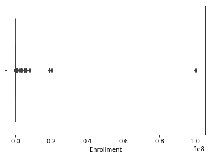

```python
# Vble Enrollment
print(data['Enrollment'].describe())
sns.boxplot(x=data['Enrollment'])
```

##### MÉTODO: Se considera outlier a aquellos valores que se encuentran +- 3 sd de la media

Imputamos a missing el valor de estas observaciones.

```
count    9.530000e+03
mean     2.189691e+03
std      3.919724e+04
min      0.000000e+00
25%      2.700000e+01
50%      6.500000e+01
75%      2.160000e+02
max      2.323608e+06
Name: Enrollment, dtype: float64
```

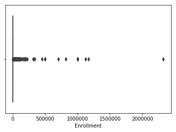

```python
data_met1 = data
sd = np.std(data_met1['Enrollment'])
data_met1.loc[data_met1['Enrollment'] < (sd * -3) , 'Enrollment'] =  np.nan
data_met1.loc[data_met1['Enrollment'] > (sd * 3) , 'Enrollment'] =  np.nan
print(data_met1['Enrollment'].describe())
sns.boxplot(x=data_met1['Enrollment'])
```

```
2323608.0
count    9.529000e+03
mean     1.946075e+03
std      3.115977e+04
min      0.000000e+00
25%      2.700000e+01
50%      6.500000e+01
75%      2.160000e+02
max      1.165781e+06
Name: Enrollment, dtype: float64
```

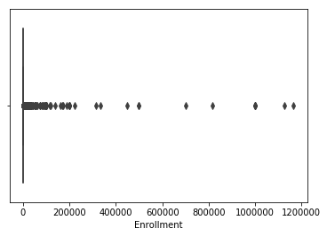

```python
# Hacemos una prueba eliminado el valor máximo de 99.999.999 y calculando nuevamente los outliers
data_met2 = data
max_en = max(data_met2['Enrollment'])
data_met2.loc[data_met2['Enrollment'] == max_en , 'Enrollment'] = np.nan
print (max_en)
print(data_met2['Enrollment'].describe())
sns.boxplot(x=data_met2['Enrollment'])
```

##### MÉTODO: Se considera outlier a aquellos valores que están +-1.5 del rango intercuartilico

Imputamos a missing el valor de estas observaciones.

```
El valor del IQR es: 189.0
count    8081.000000
mean       90.377305
std       101.768901
min         0.000000
25%        22.000000
50%        50.000000
75%       116.000000
max       498.000000
Name: Enrollment, dtype: float64
```

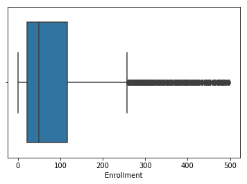

```python
data_met3 = data

Q1 = data_met3['Enrollment'].quantile(0.25)
Q3 = data_met3['Enrollment'].quantile(0.75)
IQR = Q3 - Q1

print("El valor del IQR es: {}".format(IQR))

data_met3.loc[data_met3['Enrollment'] < (Q1 - 1.5 * IQR) , 'Enrollment'] = np.nan
data_met3.loc[data_met3['Enrollment'] > (Q3 + 1.5 * IQR) , 'Enrollment'] = np.nan
print(data_met3['Enrollment'].describe())
sns.boxplot(x=data_met3['Enrollment'])
```

##### MÉTODO SELECCIONADO: aplicamos a nuestro conj de datos el método del rango intercuartílico

Imputamos a missing el valor de estas observaciones.

```
count    8910.000000
mean       66.138987
std        48.295452
min         0.000000
25%        25.000000
50%        60.000000
75%        95.730337
max       205.000000
Name: Enrollment, dtype: float64
```

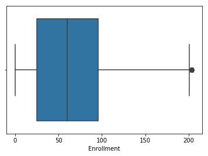

```python
Q1 = data['Enrollment'].quantile(0.25)
Q3 = data['Enrollment'].quantile(0.75)
IQR = Q3 - Q1

data.loc[data['Enrollment'] < (Q1 - 1.5 * IQR) , 'Enrollment'] = np.nan
data.loc[data['Enrollment'] > (Q3 + 1.5 * IQR) , 'Enrollment'] = np.nan
print(data['Enrollment'].describe())
sns.boxplot(x=data['Enrollment'])
```

##### Resolvemos las inconsistencias de los outlier

Aignamos a todos los missing, ya sea por el origen de la bbdd o por ser un outlier, la media del resto de observaciones.

```
count    10000.000000
mean        66.138987
std         45.587148
min          0.000000
25%         30.000000
50%         66.138987
75%         95.730337
max        205.000000
Name: Enrollment, dtype: float64
```

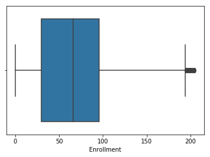

```python
data['Enrollment'] = data['Enrollment'].fillna(data['Enrollment'].mean())
print(data['Enrollment'].describe())
sns.boxplot(x=data['Enrollment'])
```

```python
# Guardamos los datos preprocesados
data1 = data
data1.keys()
```

```
Index(['Rank', 'NCT Number', 'Title', 'Acronym', 'Status', 'Study Results',
       'Conditions', 'Interventions', 'Outcome Measures',
       'Sponsor/Collaborators', 'Gender', 'Age', 'Phases', 'Enrollment',
       'Funded Bys', 'Study Type', 'Study Designs', 'Other IDs', 'Start Date',
       'Primary Completion Date', 'Completion Date', 'First Posted',
       'Results First Posted', 'Last Update Posted', 'Locations',
       'Study Documents', 'URL', 'Interventions_new', 'Locations_new',
       'Only_Childs', 'Sponsor_new', 'Sponsor_H/U', 'Study Type new',
       'Allocation', 'Model', 'Assigment', 'Masking', 'Purpose', 'Pur_treat',
       'Time_Perspective', 'Publish_Informed_Consent',
       'Publish_Study_Protocol', 'Publish_Statistical_Analysis_Plan',
       'Int_drugs', 'Location_USA', 'Fase1_2', 'Gen_mixto', 'Stu_int',
       'Status_Compl', 'Results_yes'],
      dtype='object')
```

### 3.2.2. Análisis Exploratorio de Datos

#### 3.2.2.1. Análisis Univariable

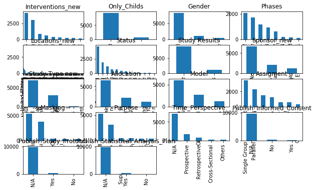

```python
vbles_cat = data.loc[:, ['Interventions_new', 'Only_Childs', 'Gender', 'Phases', 'Locations_new',
                         'Status', 'Study Results', 'Sponsor_new', 'Study Type new',
                          'Allocation', 'Model', 'Assigment', 'Masking', 'Purpose', 'Time_Perspective',
                         'Publish_Informed_Consent', 'Publish_Study_Protocol', 'Publish_Statistical_Analysis_Plan']]

i=1
plt.figure(figsize=(10, 6))
for col in vbles_cat:
    plt.subplot(5,4,i)
    graf = vbles_cat [col].value_counts().plot(kind='bar')
    plt.title(vbles_cat.columns[i-1])
    i=i+1
plt.show()
```

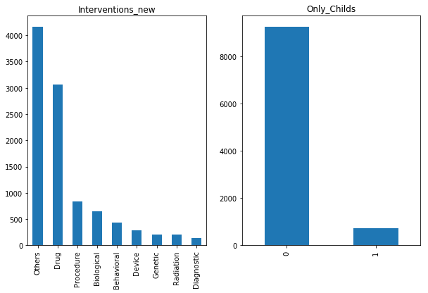

```python
vbles = data.loc[:, ['Interventions_new', 'Only_Childs']]
i=1
plt.figure(figsize=(10, 6))
for col in vbles:
    plt.subplot(1,2,i)
    graf = vbles [col].value_counts().plot(kind='bar')
    plt.title(vbles.columns[i-1])
    #plt.subplots_adjust (left=0.11, bottom=0.24, right=0.90, top=0.90, wspace=0.2, hspace=0)
    i=i+1

plt.show()
```

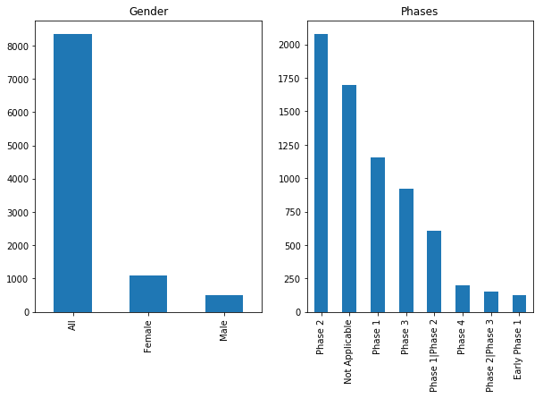

```python
vbles = data.loc[:, ['Gender','Phases']]
i=1
plt.figure(figsize=(10, 6))
for col in vbles:
    plt.subplot(1,2,i)
    graf = vbles [col].value_counts().plot(kind='bar')
    plt.title(vbles.columns[i-1])
    #plt.subplots_adjust (left=0.11, bottom=0.24, right=0.90, top=0.90, wspace=0.2, hspace=0)
    i=i+1

plt.show()
```

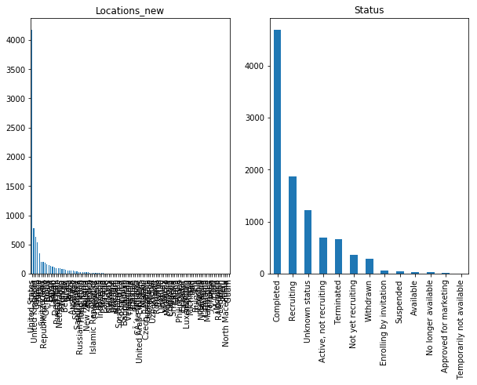

```python
vbles = data.loc[:, ['Locations_new','Status']]
i=1
plt.figure(figsize=(10, 6))
for col in vbles:
    plt.subplot(1,2,i)
    graf = vbles [col].value_counts().plot(kind='bar')
    plt.title(vbles.columns[i-1])
    #plt.subplots_adjust (left=0.11, bottom=0.24, right=0.90, top=0.90, wspace=0.2, hspace=0)
    i=i+1

plt.show()
```

[figure not shown]

```python
vbles = data.loc[:, ['Study Results', 'Sponsor_new']]
i=1
plt.figure(figsize=(10, 6))
for col in vbles:
    plt.subplot(1,2,i)
    graf = vbles [col].value_counts().plot(kind='bar')
    plt.title(vbles.columns[i-1])
    #plt.subplots_adjust (left=0.11, bottom=0.24, right=0.90, top=0.90, wspace=0.2, hspace=0)
    i=i+1

plt.show()
```

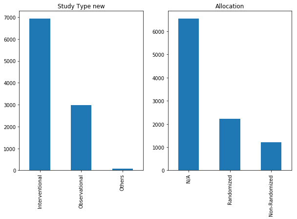

```python
vbles = data.loc[:, ['Study Type new','Allocation']]
i=1
plt.figure(figsize=(10, 6))
for col in vbles:
    plt.subplot(1,2,i)
    graf = vbles [col].value_counts().plot(kind='bar')
    plt.title(vbles.columns[i-1])
    #plt.subplots_adjust (left=0.11, bottom=0.24, right=0.90, top=0.90, wspace=0.2, hspace=0)
    i=i+1

plt.show()
```

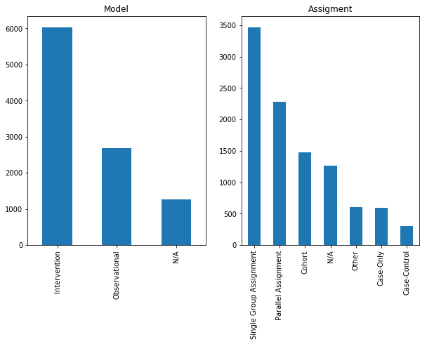

```python
vbles = data.loc[:, ['Model','Assigment']]
i=1
plt.figure(figsize=(10, 6))
for col in vbles:
    plt.subplot(1,2,i)
    graf = vbles [col].value_counts().plot(kind='bar')
    plt.title(vbles.columns[i-1])
    #plt.subplots_adjust (left=0.11, bottom=0.24, right=0.90, top=0.90, wspace=0.2, hspace=0)
    i=i+1

plt.show()
```

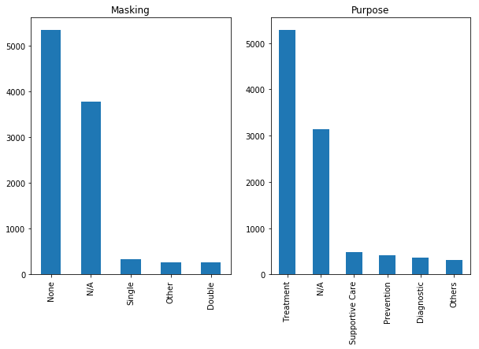

```python
vbles = data.loc[:, ['Masking','Purpose']]
i=1
plt.figure(figsize=(10, 6))
for col in vbles:
    plt.subplot(1,2,i)
    graf = vbles [col].value_counts().plot(kind='bar')
    plt.title(vbles.columns[i-1])
    #plt.subplots_adjust (left=0.11, bottom=0.24, right=0.90, top=0.90, wspace=0.2, hspace=0)
    i=i+1

plt.show()
```

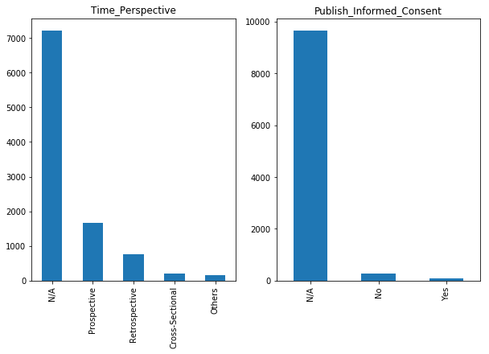

```python
vbles = data.loc[:, ['Time_Perspective','Publish_Informed_Consent']]
i=1
plt.figure(figsize=(10, 6))
for col in vbles:
    plt.subplot(1,2,i)
    graf = vbles [col].value_counts().plot(kind='bar')
    plt.title(vbles.columns[i-1])
    #plt.subplots_adjust (left=0.11, bottom=0.24, right=0.90, top=0.90, wspace=0.2, hspace=0)
    i=i+1

plt.show()
```

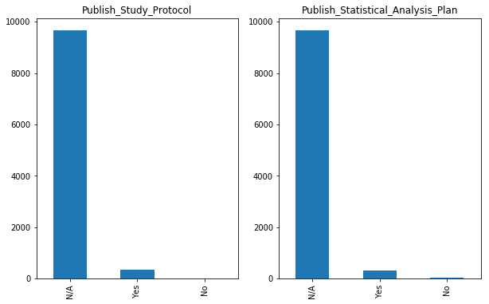

```python
vbles = data.loc[:, ['Publish_Study_Protocol','Publish_Statistical_Analysis_Plan']]
i=1
plt.figure(figsize=(10, 6))
for col in vbles:
    plt.subplot(1,2,i)
    graf = vbles [col].value_counts().plot(kind='bar')
    plt.title(vbles.columns[i-1])
    #plt.subplots_adjust (left=0.11, bottom=0.24, right=0.90, top=0.90, wspace=0.2, hspace=0)
    i=i+1

plt.show()
```

##### Variables cuantitativas

```python
# Vble existente: Enrollment
# Nuevas vbles: 'Duration', 'Duration_real', 'Time_First_Posted', 'Time_Last_Posted', 'yrs_Study'

vbles_num = data.loc[:, ['Enrollment', 'Duration', 'Duration_real', 'Time_First_Posted', 'Time_Last_Posted', 'yrs_Study']]
vbles_num.describe()
```

|  | Enrollment | Duration | Duration_real | Time_First_Posted | Time_Last_Posted | yrs_Study |
| --- | --- | --- | --- | --- | --- | --- |
| count | 10000.000000 | 8987.000000 | 8801.000000 | 9836.000000 | 10000.000000 | 9836.000000 |
| mean | 66.138987 | 4.429064 | 5.279855 | 1.165921 | 4.118000 | 10.661041 |
| std | 45.587148 | 5.644580 | 5.657795 | 3.839897 | 3.805118 | 7.752369 |
| min | 0.000000 | 0.000000 | 0.000000 | -90.000000 | 0.000000 | -79.000000 |
| 25% | 30.000000 | 1.000000 | 2.000000 | -1.000000 | 1.000000 | 4.000000 |
| 50% | 66.138987 | 3.000000 | 4.000000 | 0.000000 | 3.000000 | 10.000000 |
| 75% | 95.730337 | 6.000000 | 7.000000 | 2.000000 | 7.000000 | 16.000000 |
| max | 205.000000 | 99.000000 | 94.000000 | 47.000000 | 16.000000 | 50.000000 |

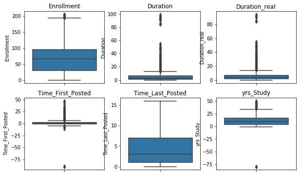

```python
i=1
plt.figure(figsize=(10, 6))
for col in vbles_num:
    plt.subplot(2,3,i)
    graf = sns.boxplot(y=vbles_num[col])
    plt.title(vbles_num.columns[i-1])
    i=i+1
plt.show()
```

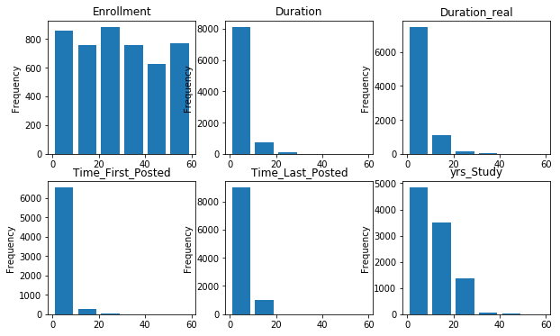

```python
i=1
plt.figure(figsize=(10, 6))
for col in vbles_num:
    plt.subplot(2,3,i)
    graf = vbles_num [col].plot(kind='hist',bins=[0,10,20,30,40,50,60],rwidth=0.8)
    plt.title(vbles_num.columns[i-1])
    i=i+1

plt.show()
```

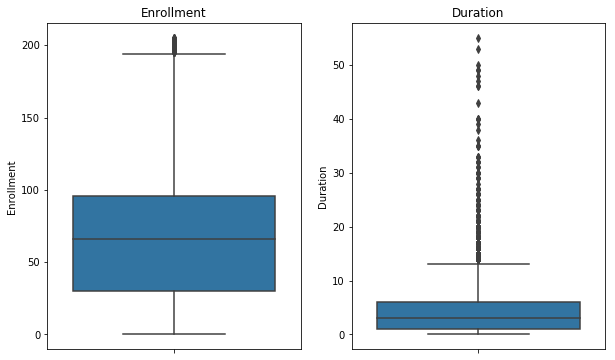

```python
vbles_graf =  data.loc[:, ['Enrollment','Duration']]
i=1
plt.figure(figsize=(10, 6))
for col in vbles_graf:
    plt.subplot(1,2,i)
    graf = sns.boxplot(y=vbles_graf[col])
    #graf = vbles_num [col].plot(kind='hist',bins=[0,10,20,30,40,50,60],rwidth=0.8)
    plt.title(vbles_graf.columns[i-1])
    i=i+1
plt.show()
```

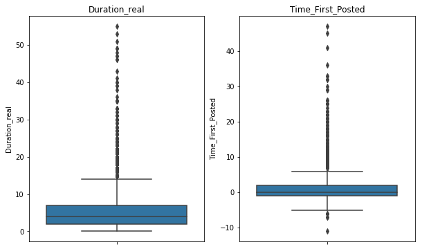

```python
vbles_graf =  data.loc[:, ['Duration_real','Time_First_Posted']]
i=1
plt.figure(figsize=(10, 6))
for col in vbles_graf:
    plt.subplot(1,2,i)
    graf = sns.boxplot(y=vbles_graf[col])
    #graf = vbles_num [col].plot(kind='hist',bins=[0,10,20,30,40,50,60],rwidth=0.8)
    plt.title(vbles_graf.columns[i-1])
    i=i+1
plt.show()
```

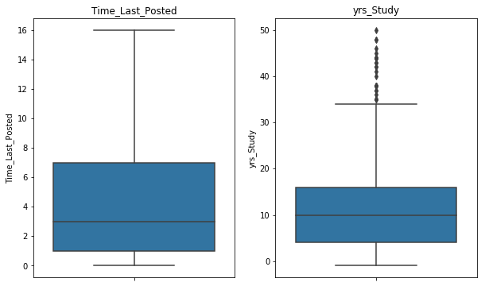

```python
vbles_graf =  data.loc[:, ['Time_Last_Posted', 'yrs_Study']]
i=1
plt.figure(figsize=(10, 6))
for col in vbles_graf:
    plt.subplot(1,2,i)
    graf = sns.boxplot(y=vbles_graf[col])
    #graf = vbles_num [col].plot(kind='hist',bins=[0,10,20,30,40,50,60],rwidth=0.8)
    plt.title(vbles_graf.columns[i-1])
    i=i+1
plt.show()
```

### 3.2.2. Análisis Exploratorio de Datos

#### 3.2.2.2. Análisis Bivariable

##### Variables cuantitativas

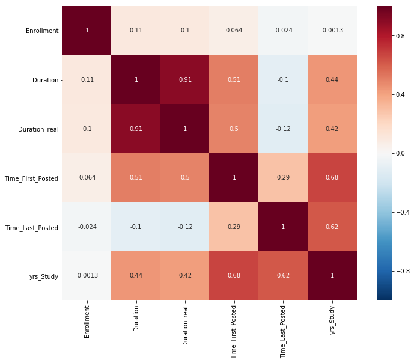

```python
# Matriz de correlación
vbles_num = data.loc[:, ['Enrollment', 'Duration', 'Duration_real', 'Time_First_Posted', 'Time_Last_Posted', 'yrs_Study']]

corrmat = vbles_num.corr()
f, ax = plt.subplots(figsize=(12, 9))
sns.heatmap(corrmat, vmin=-1.0, vmax=1.0, annot=True, square=True, cmap='RdBu_r');
```

##### Variables cualitativas

```python
# Definimos 3 macros para 3 tablas de contingencia

# Tabla de contingencia
def tabla_cont (vble1, vble2):
    return pd.crosstab(index = data[vble1], columns=data[vble2], margins=True)

# tabla de contingencia en porcentajes relativos total
def tabla_cont_pctn (vble1, vble2):
    return pd.crosstab(index = data[vble1],columns=data[vble2], margins=True).apply(lambda r: r/len(data) *100, axis=1)

# tabla de contingencia en porcentajes relativos segun fila (vble1)
def tabla_cont_rowpctn (vble1, vble2):
    return pd.crosstab(index = data[vble1],columns=data[vble2]).apply(lambda r: r/r.sum() *100, axis=1)

# tabla de contingencia en porcentajes relativos segun fila (vble1)
def tabla_cont_colpctn (vble1, vble2):
    return pd.crosstab(index = data[vble1],columns=data[vble2]).apply(lambda r: r/r.sum() *100, axis=0)
```

```python
# Se estudia la variable Study Type y la nueva variable Model para validar si aportan la misma información
tabla_cont ('Study Type new','Model')
```

| Model Study Type new | Intervention | N/A | Observational | All |
| --- | --- | --- | --- | --- |
| Interventional | 6037 | 900 | 0 | 6937 |
| Observational | 0 | 284 | 2694 | 2978 |
| Others | 0 | 85 | 0 | 85 |
| All | 6037 | 1269 | 2694 | 10000 |

```python
print(tabla_cont ('Study Type new','Model'))
print(tabla_cont_pctn ('Study Type new','Model'))
print(tabla_cont_rowpctn ('Study Type new','Model'))
print(tabla_cont_colpctn ('Study Type new','Model'))
```

```
Model           Intervention   N/A  Observational    All
Study Type new
Interventional          6037   900              0   6937
Observational              0   284           2694   2978
Others                     0    85              0     85
All                     6037  1269           2694  10000
Model           Intervention    N/A  Observational     All
Study Type new
Interventional         60.37   9.00           0.00   69.37
Observational           0.00   2.84          26.94   29.78
Others                  0.00   0.85           0.00    0.85
All                    60.37  12.69          26.94  100.00
Model           Intervention         N/A  Observational
Study Type new
Interventional     87.026092   12.973908       0.000000
Observational       0.000000    9.536602      90.463398
Others              0.000000  100.000000       0.000000
Model           Intervention        N/A  Observational
Study Type new
Interventional         100.0  70.921986            0.0
Observational            0.0  22.379827          100.0
Others                   0.0   6.698188            0.0
```

```python
tabla_cont_pctn ('Study Type new','Assigment')
```

| Assigment Study Type new | Case-Control | Case-Only | Cohort | N/A | Other | Parallel Assignment | Single Group Assignment | All |
| --- | --- | --- | --- | --- | --- | --- | --- | --- |
| Interventional | 0.00 | 0.00 | 0.0 | 9.00 | 2.87 | 22.8 | 34.7 | 69.37 |
| Observational | 3.07 | 5.93 | 14.8 | 2.84 | 3.14 | 0.0 | 0.0 | 29.78 |
| Others | 0.00 | 0.00 | 0.0 | 0.85 | 0.00 | 0.0 | 0.0 | 0.85 |
| All | 3.07 | 5.93 | 14.8 | 12.69 | 6.01 | 22.8 | 34.7 | 100.00 |

```python
tabla_cont_pctn ('Assigment','Masking')
```

| Masking Assigment | Double | N/A | None | Other | Single | All |
| --- | --- | --- | --- | --- | --- | --- |
| Case-Control | 0.00 | 3.07 | 0.00 | 0.00 | 0.00 | 3.07 |
| Case-Only | 0.00 | 5.93 | 0.00 | 0.00 | 0.00 | 5.93 |
| Cohort | 0.00 | 14.80 | 0.00 | 0.00 | 0.00 | 14.80 |
| N/A | 0.16 | 10.70 | 1.80 | 0.01 | 0.02 | 12.69 |
| Other | 0.24 | 3.14 | 2.13 | 0.26 | 0.24 | 6.01 |
| Parallel Assignment | 2.08 | 0.14 | 15.53 | 2.33 | 2.72 | 22.80 |
| Single Group Assignment | 0.12 | 0.07 | 34.11 | 0.04 | 0.36 | 34.70 |
| All | 2.60 | 37.85 | 53.57 | 2.64 | 3.34 | 100.00 |

```python
tabla_cont_pctn ('Assigment','Purpose')
```

| Purpose Assigment | Diagnostic | N/A | Others | Prevention | Supportive Care | Treatment | All |
| --- | --- | --- | --- | --- | --- | --- | --- |
| Case-Control | 0.00 | 3.07 | 0.00 | 0.00 | 0.00 | 0.00 | 3.07 |
| Case-Only | 0.00 | 5.93 | 0.00 | 0.00 | 0.00 | 0.00 | 5.93 |
| Cohort | 0.00 | 14.80 | 0.00 | 0.00 | 0.00 | 0.00 | 14.80 |
| N/A | 0.21 | 3.82 | 0.05 | 0.13 | 0.64 | 7.84 | 12.69 |
| Other | 0.10 | 3.21 | 0.20 | 0.26 | 0.28 | 1.96 | 6.01 |
| Parallel Assignment | 0.67 | 0.31 | 1.41 | 2.79 | 2.83 | 14.79 | 22.80 |
| Single Group Assignment | 2.62 | 0.22 | 1.45 | 1.04 | 1.09 | 28.28 | 34.70 |
| All | 3.60 | 31.36 | 3.11 | 4.22 | 4.84 | 52.87 | 100.00 |

```python
tabla_cont_pctn ('Masking','Purpose')
```

| Purpose Masking | Diagnostic | N/A | Others | Prevention | Supportive Care | Treatment | All |
| --- | --- | --- | --- | --- | --- | --- | --- |
| Double | 0.03 | 0.03 | 0.17 | 0.64 | 0.46 | 1.27 | 2.60 |
| N/A | 0.18 | 30.77 | 0.04 | 0.08 | 0.38 | 6.40 | 37.85 |
| None | 3.03 | 0.46 | 2.38 | 2.42 | 3.00 | 42.28 | 53.57 |
| Other | 0.07 | 0.01 | 0.11 | 0.56 | 0.44 | 1.45 | 2.64 |
| Single | 0.29 | 0.09 | 0.41 | 0.52 | 0.56 | 1.47 | 3.34 |
| All | 3.60 | 31.36 | 3.11 | 4.22 | 4.84 | 52.87 | 100.00 |

```python
tabla_cont ('Interventions_new','Purpose')
```

| Purpose Interventions_new | Diagnostic | N/A | Others | Prevention | Supportive Care | Treatment | All |
| --- | --- | --- | --- | --- | --- | --- | --- |
| Behavioral | 8 | 94 | 48 | 74 | 151 | 55 | 430 |
| Biological | 6 | 37 | 10 | 103 | 8 | 486 | 650 |
| Device | 60 | 67 | 21 | 13 | 16 | 110 | 287 |
| Diagnostic | 36 | 99 | 5 | 0 | 0 | 1 | 141 |
| Drug | 46 | 268 | 40 | 126 | 94 | 2491 | 3065 |
| Genetic | 6 | 174 | 11 | 2 | 0 | 19 | 212 |
| Others | 118 | 2029 | 127 | 77 | 161 | 1653 | 4165 |
| Procedure | 73 | 321 | 43 | 26 | 51 | 329 | 843 |
| Radiation | 7 | 47 | 6 | 1 | 3 | 143 | 207 |
| All | 360 | 3136 | 311 | 422 | 484 | 5287 | 10000 |

```python
print(tabla_cont ('Interventions_new','Purpose'))
print(tabla_cont_pctn ('Interventions_new','Purpose'))
print(tabla_cont_rowpctn ('Interventions_new','Purpose'))
print(tabla_cont_colpctn ('Interventions_new','Purpose'))
```

```
Purpose            Diagnostic   N/A  Others  Prevention  Supportive Care  \
Interventions_new
Behavioral                  8    94      48          74              151
Biological                  6    37      10         103                8
Device                     60    67      21          13               16
Diagnostic                 36    99       5           0                0
Drug                       46   268      40         126               94
Genetic                     6   174      11           2                0
Others                    118  2029     127          77              161
Procedure                  73   321      43          26               51
Radiation                   7    47       6           1                3
All                       360  3136     311         422              484

Purpose            Treatment    All
Interventions_new
Behavioral                55    430
Biological               486    650
Device                   110    287
Diagnostic                 1    141
Drug                    2491   3065
Genetic                   19    212
Others                  1653   4165
Procedure                329    843
Radiation                143    207
All                     5287  10000
Purpose            Diagnostic    N/A  Others  Prevention  Supportive Care  \
Interventions_new
Behavioral               0.08   0.94    0.48        0.74             1.51
Biological               0.06   0.37    0.10        1.03             0.08
Device                   0.60   0.67    0.21        0.13             0.16
Diagnostic               0.36   0.99    0.05        0.00             0.00
Drug                     0.46   2.68    0.40        1.26             0.94
Genetic                  0.06   1.74    0.11        0.02             0.00
Others                   1.18  20.29    1.27        0.77             1.61
Procedure                0.73   3.21    0.43        0.26             0.51
Radiation                0.07   0.47    0.06        0.01             0.03
All                      3.60  31.36    3.11        4.22             4.84

Purpose            Treatment     All
Interventions_new
```

[output cut: 41 more lines]

```
Others              32.777778  64.700255  40.836013   18.246445
Procedure           20.277778  10.235969  13.826367    6.161137
Radiation            1.944444   1.498724   1.929260    0.236967

Purpose            Supportive Care  Treatment
Interventions_new
Behavioral               31.198347   1.040287
Biological                1.652893   9.192359
Device                    3.305785   2.080575
Diagnostic                0.000000   0.018914
Drug                     19.421488  47.115566
Genetic                   0.000000   0.359372
Others                   33.264463  31.265368
Procedure                10.537190   6.222811
Radiation                 0.619835   2.704747
```

```python
tabla_cont_pctn ('Status','Purpose')
```

| Purpose Status | Diagnostic | N/A | Others | Prevention | Supportive Care | Treatment | All |
| --- | --- | --- | --- | --- | --- | --- | --- |
| Active, not recruiting | 0.23 | 1.86 | 0.12 | 0.28 | 0.38 | 4.13 | 7.00 |
| Approved for marketing | 0.00 | 0.13 | 0.00 | 0.00 | 0.00 | 0.00 | 0.13 |
| Available | 0.00 | 0.36 | 0.00 | 0.00 | 0.00 | 0.00 | 0.36 |
| Completed | 1.25 | 14.48 | 1.26 | 2.28 | 2.50 | 25.07 | 46.84 |
| Enrolling by invitation | 0.02 | 0.35 | 0.05 | 0.03 | 0.02 | 0.15 | 0.62 |
| No longer available | 0.00 | 0.34 | 0.00 | 0.00 | 0.00 | 0.00 | 0.34 |
| Not yet recruiting | 0.21 | 1.15 | 0.25 | 0.19 | 0.17 | 1.67 | 3.64 |
| Recruiting | 0.62 | 6.26 | 0.84 | 0.64 | 0.73 | 9.60 | 18.69 |
| Suspended | 0.03 | 0.11 | 0.02 | 0.02 | 0.05 | 0.24 | 0.47 |
| Temporarily not available | 0.00 | 0.02 | 0.00 | 0.00 | 0.00 | 0.00 | 0.02 |
| Terminated | 0.34 | 1.01 | 0.11 | 0.19 | 0.42 | 4.62 | 6.69 |
| Unknown status | 0.74 | 4.51 | 0.34 | 0.53 | 0.39 | 5.74 | 12.25 |
| Withdrawn | 0.16 | 0.78 | 0.12 | 0.06 | 0.18 | 1.65 | 2.95 |
| All | 3.60 | 31.36 | 3.11 | 4.22 | 4.84 | 52.87 | 100.00 |

```python
tabla_cont ('Study Results','Purpose')
```

| Purpose Study Results | Diagnostic | N/A | Others | Prevention | Supportive Care | Treatment | All |
| --- | --- | --- | --- | --- | --- | --- | --- |
| Has Results | 33 | 67 | 24 | 89 | 46 | 835 | 1094 |
| No Results Available | 327 | 3069 | 287 | 333 | 438 | 4452 | 8906 |
| All | 360 | 3136 | 311 | 422 | 484 | 5287 | 10000 |

```python
tabla_cont_pctn ('Status','Sponsor_new')
```

| Sponsor_new Status | Hospital | Others | University | All |
| --- | --- | --- | --- | --- |
| Active, not recruiting | 0.89 | 5.01 | 1.10 | 7.00 |
| Approved for marketing | 0.00 | 0.11 | 0.02 | 0.13 |
| Available | 0.02 | 0.28 | 0.06 | 0.36 |
| Completed | 4.50 | 33.11 | 9.23 | 46.84 |
| Enrolling by invitation | 0.11 | 0.38 | 0.13 | 0.62 |
| No longer available | 0.01 | 0.30 | 0.03 | 0.34 |
| Not yet recruiting | 0.57 | 1.87 | 1.20 | 3.64 |
| Recruiting | 3.14 | 11.07 | 4.48 | 18.69 |
| Suspended | 0.05 | 0.32 | 0.10 | 0.47 |
| Temporarily not available | 0.00 | 0.02 | 0.00 | 0.02 |
| Terminated | 0.75 | 4.32 | 1.62 | 6.69 |
| Unknown status | 1.74 | 8.01 | 2.50 | 12.25 |
| Withdrawn | 0.37 | 1.79 | 0.79 | 2.95 |
| All | 12.15 | 66.59 | 21.26 | 100.00 |

```python
tabla_cont_pctn ('Study Results','Sponsor_new')
```

| Sponsor_new Study Results | Hospital | Others | University | All |
| --- | --- | --- | --- | --- |
| Has Results | 0.87 | 8.23 | 1.84 | 10.94 |
| No Results Available | 11.28 | 58.36 | 19.42 | 89.06 |
| All | 12.15 | 66.59 | 21.26 | 100.00 |

```python
tabla_cont ('Status','Study Results')
```

| Study Results Status | Has Results | No Results Available | All |
| --- | --- | --- | --- |
| Active, not recruiting | 77 | 623 | 700 |
| Approved for marketing | 0 | 13 | 13 |
| Available | 0 | 36 | 36 |
| Completed | 760 | 3924 | 4684 |
| Enrolling by invitation | 0 | 62 | 62 |
| No longer available | 0 | 34 | 34 |
| Not yet recruiting | 0 | 364 | 364 |
| Recruiting | 0 | 1869 | 1869 |
| Suspended | 0 | 47 | 47 |
| Temporarily not available | 0 | 2 | 2 |
| Terminated | 247 | 422 | 669 |
| Unknown status | 10 | 1215 | 1225 |
| Withdrawn | 0 | 295 | 295 |
| All | 1094 | 8906 | 10000 |

```python
tabla_cont ('Status', 'Only_Childs')
```

| Only_Childs Status | 0 | 1 | All |
| --- | --- | --- | --- |
| Active, not recruiting | 655 | 45 | 700 |
| Approved for marketing | 13 | 0 | 13 |
| Available | 35 | 1 | 36 |
| Completed | 4348 | 336 | 4684 |
| Enrolling by invitation | 57 | 5 | 62 |
| No longer available | 31 | 3 | 34 |
| Not yet recruiting | 322 | 42 | 364 |
| Recruiting | 1745 | 124 | 1869 |
| Suspended | 45 | 2 | 47 |
| Temporarily not available | 2 | 0 | 2 |
| Terminated | 620 | 49 | 669 |
| Unknown status | 1144 | 81 | 1225 |
| Withdrawn | 257 | 38 | 295 |
| All | 9274 | 726 | 10000 |

```python
print(tabla_cont ('Status', 'Only_Childs'))
print(tabla_cont_pctn ('Status', 'Only_Childs'))
print(tabla_cont_rowpctn ('Status', 'Only_Childs'))
print(tabla_cont_colpctn ('Status', 'Only_Childs'))
```

```
Only_Childs                   0    1    All
Status
Active, not recruiting      655   45    700
Approved for marketing       13    0     13
Available                    35    1     36
Completed                  4348  336   4684
Enrolling by invitation      57    5     62
No longer available          31    3     34
Not yet recruiting          322   42    364
Recruiting                 1745  124   1869
Suspended                    45    2     47
Temporarily not available     2    0      2
Terminated                  620   49    669
Unknown status             1144   81   1225
Withdrawn                   257   38    295
All                        9274  726  10000
Only_Childs                    0     1     All
Status
Active, not recruiting      6.55  0.45    7.00
Approved for marketing      0.13  0.00    0.13
Available                   0.35  0.01    0.36
Completed                  43.48  3.36   46.84
Enrolling by invitation     0.57  0.05    0.62
No longer available         0.31  0.03    0.34
Not yet recruiting          3.22  0.42    3.64
Recruiting                 17.45  1.24   18.69
Suspended                   0.45  0.02    0.47
Temporarily not available   0.02  0.00    0.02
Terminated                  6.20  0.49    6.69
Unknown status             11.44  0.81   12.25
Withdrawn                   2.57  0.38    2.95
All                        92.74  7.26  100.00
Only_Childs                         0          1
Status
Active, not recruiting      93.571429   6.428571
Approved for marketing     100.000000   0.000000
Available                   97.222222   2.777778
Completed                   92.826644   7.173356
Enrolling by invitation     91.935484   8.064516
No longer available         91.176471   8.823529
Not yet recruiting          88.461538  11.538462
Recruiting                  93.365436   6.634564
Suspended                   95.744681   4.255319
Temporarily not available  100.000000   0.000000
Terminated                  92.675635   7.324365
Unknown status              93.387755   6.612245
Withdrawn                   87.118644  12.881356
Only_Childs                        0          1
Status
Active, not recruiting      7.062756   6.198347
Approved for marketing      0.140177   0.000000
Available                   0.377399   0.137741
Completed                  46.883761  46.280992
Enrolling by invitation     0.614622   0.688705
No longer available         0.334268   0.413223
Not yet recruiting          3.472072   5.785124
Recruiting                 18.816045  17.079890
Suspended                   0.485228   0.275482
Temporarily not available   0.021566   0.000000
Terminated                  6.685357   6.749311
Unknown status             12.335562  11.157025
Withdrawn                   2.771188   5.234160
```

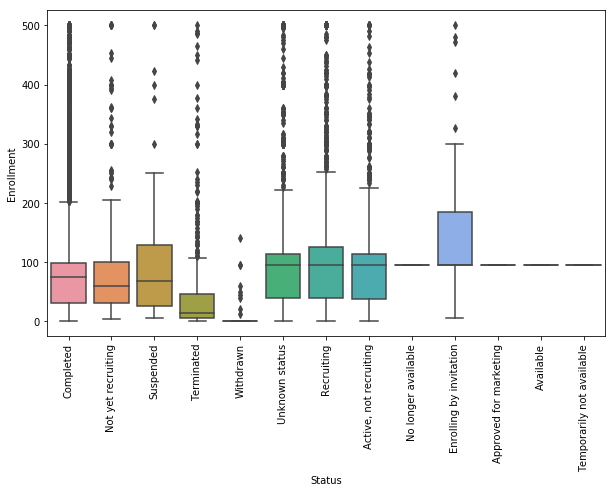

```python
var = 'Status'
f, ax = plt.subplots(figsize=(10, 6))
fig = sns.boxplot(x=var, y="Enrollment", data=data)
plt.xticks(rotation=90);
```

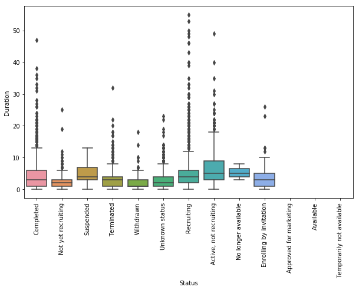

```python
var = 'Status'
f, ax = plt.subplots(figsize=(10, 6))
fig = sns.boxplot(x=var, y="Duration", data=data)
plt.xticks(rotation=90);
```

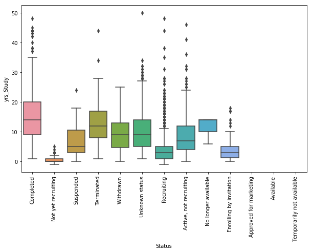

```python
var = 'Status'
f, ax = plt.subplots(figsize=(10, 6))
fig = sns.boxplot(x=var, y="yrs_Study", data=data)
plt.xticks(rotation=90);
```

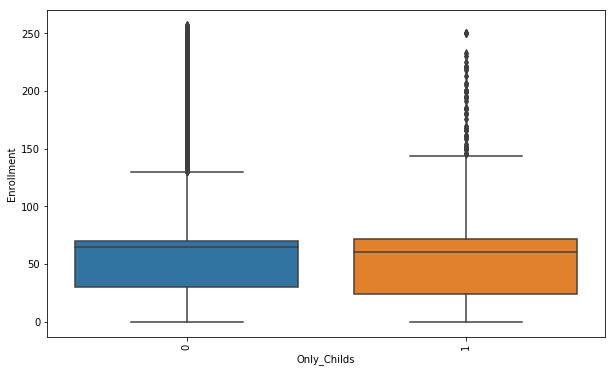

```python
var = 'Only_Childs'
f, ax = plt.subplots(figsize=(10, 6))
fig = sns.boxplot(x=var, y="Enrollment", data=data)
plt.xticks(rotation=90);
```

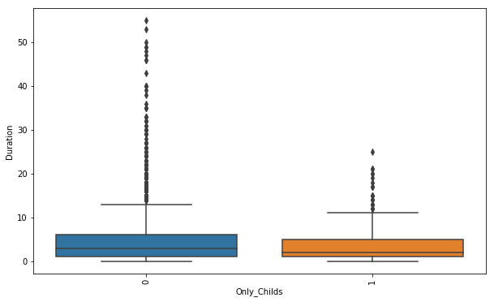

```python
var = 'Only_Childs'
f, ax = plt.subplots(figsize=(10, 6))
fig = sns.boxplot(x=var, y="Duration", data=data)
plt.xticks(rotation=90);
```

```python
data_des = data.loc[:, ['Only_Childs','Enrollment', 'Duration']]
data_des.groupby('Only_Childs').describe()
# ANOVA: hay diferencia en la duración de un en clínico solo en niños y otr de niños + adultos?
```

| Only_Childs | Enrollment count | Enrollment mean | Enrollment std | Enrollment min | Enrollment 25% | Enrollment 50% | Enrollment 75% | Enrollment max | Duration count | Duration mean | Duration std | Duration min | Duration 25% | Duration 50% | Duration 75% | Duration max |
| --- | --- | --- | --- | --- | --- | --- | --- | --- | --- | --- | --- | --- | --- | --- | --- | --- |
| 0 | 9274.0 | 65.353964 | 51.931585 | 0.0 | 30.0 | 65.119458 | 70.0 | 257.0 | 8300.0 | 4.353855 | 4.566042 | 0.0 | 1.0 | 3.0 | 6.0 | 55.0 |
| 1 | 726.0 | 62.123855 | 51.274656 | 0.0 | 24.0 | 60.000000 | 72.0 | 250.0 | 670.0 | 3.580597 | 3.560527 | 0.0 | 1.0 | 2.0 | 5.0 | 25.0 |

## 3.3 ANÁLISIS DE DATOS

```python
# Asignamos la media a los na para no tener q eliminar registros a la hora de modelar.
data['Enrollment'] = data['Enrollment'].fillna(data['Enrollment'].mean())
data['Duration'] = data['Duration'].fillna(data['Duration'].mean())
data['Duration_real'] = data['Duration_real'].fillna(data['Duration_real'].mean())
data['Time_First_Posted'] = data['Time_First_Posted'].fillna(data['Time_First_Posted'].mean())
data['yrs_Study'] = data['yrs_Study'].fillna(data['yrs_Study'].mean())
```

### 3.3.1. Agrupamiento jerárquico

https://scikit-learn.org/stable/modules/clustering.html#clustering

##### Generamos el conjunto de datos

Se modeliza con el conjunto original con las variables categóricas.

```python
data_model = data.loc[:, ['Interventions_new','Gender', 'Phases', 'Locations_new', 'Status',
                          'Study Results', 'Sponsor_new', 'Study Type new', 'Purpose', 'Only_Childs',
                          #'Assigment', 'Masking',
                          #'Time_First_Posted', 'Time_Last_Posted',
                          'Enrollment', 'Duration', 'yrs_Study']]
data_model.dtypes

# Eliminamos registros con valor na porque sino los modelos no funcionan ni podemos recodificar las variables categoricas
X = data_model.dropna(axis=0)
print(data_model.shape)
print(X.shape)

# Recodificamos las variables categóricas para el modelo NO supervisado
for i in range(0,10):
        X.iloc[:,i] = X.iloc[:,i].astype('category')

for i in range(0,10):
        X.iloc[:,i] = X.iloc[:,i].cat.codes

X.head(5)
```

```
(10000, 13)
(6391, 13)
```

|  | Interventions_new | Gender | Phases | Locations_new | Status | Study Results | Sponsor_new | Study Type new | Purpose | Only_Childs | Enrollment | Duration | yrs_Study |
| --- | --- | --- | --- | --- | --- | --- | --- | --- | --- | --- | --- | --- | --- |
| 0 | 0 | 0 | 4 | 82 | 1 | 1 | 2 | 0 | 3 | 1 | 65.119458 | 3.000000 | 18.0 |
| 3 | 1 | 1 | 1 | 75 | 1 | 1 | 1 | 0 | 3 | 1 | 65.119458 | 1.000000 | 10.0 |
| 4 | 0 | 0 | 0 | 82 | 1 | 1 | 1 | 0 | 4 | 1 | 20.000000 | 1.000000 | 8.0 |
| 5 | 6 | 0 | 6 | 34 | 1 | 1 | 1 | 0 | 5 | 1 | 65.119458 | 4.296098 | 23.0 |
| 6 | 0 | 0 | 1 | 7 | 1 | 1 | 0 | 0 | 5 | 1 | 184.000000 | 4.000000 | 10.0 |

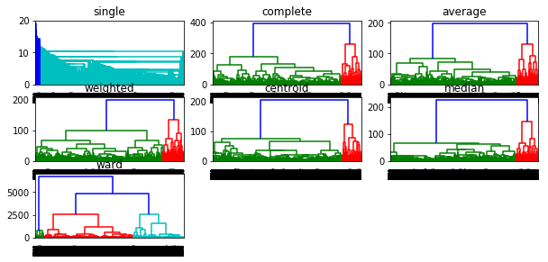

```python
link_list = ['single', 'complete', 'average', 'weighted', 'centroid', 'median', 'ward']

plt.figure(figsize=(10, 6))

for i in range (1,len(link_list)+1):
    plt.subplot(4,3,i)
    dendrogram(linkage(X, link_list[i-1]))
    plt.title(link_list[i-1])
    i=i+1
plt.show()

# linkage = distancia que se tiene en cuenta entre los grupos:
# 'single'   punto mas cercano
# 'complete' punto más alejado
# 'average'  promedio
# 'weighted' ponderado
# 'centroid' por centroides
# 'median'   por centrodides en mediana
# 'ward'     por grupos
```

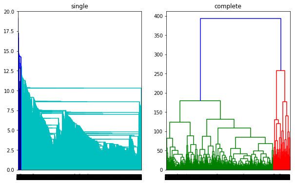

```python
link_list = ['single', 'complete']

plt.figure(figsize=(10, 6))

for i in range (1,len(link_list)+1):
    plt.subplot(1,2,i)
    dendrogram(linkage(X, link_list[i-1]))
    plt.title(link_list[i-1])
    i=i+1

plt.show()
```

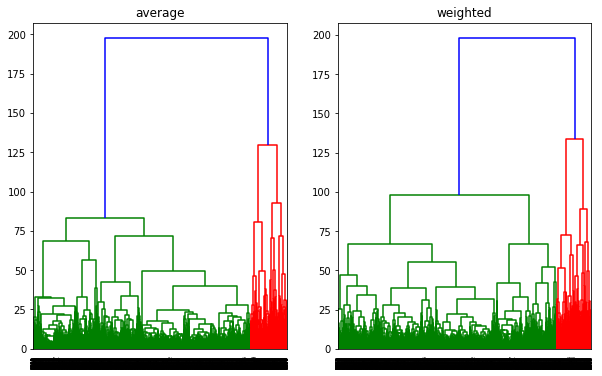

```python
link_list = ['average', 'weighted']

plt.figure(figsize=(10, 6))

for i in range (1,len(link_list)+1):
    plt.subplot(1,2,i)
    dendrogram(linkage(X, link_list[i-1]))
    plt.title(link_list[i-1])
    i=i+1

plt.show()
```

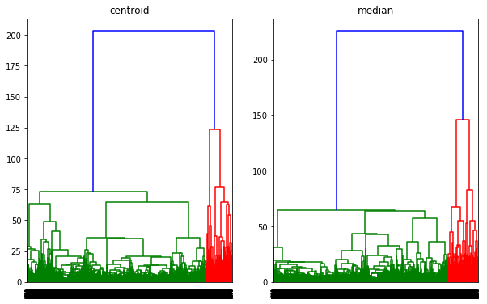

```python
link_list = ['centroid', 'median']

plt.figure(figsize=(10, 6))

for i in range (1,len(link_list)+1):
    plt.subplot(1,2,i)
    dendrogram(linkage(X, link_list[i-1]))
    plt.title(link_list[i-1])
    i=i+1

plt.show()
```

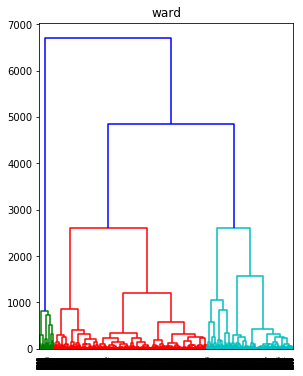

```python
link_list = ['ward']

plt.figure(figsize=(10, 6))

for i in range (1,len(link_list)+1):
    plt.subplot(1,2,i)
    dendrogram(linkage(X, link_list[i-1]))
    plt.title(link_list[i-1])
    i=i+1

plt.show()
```